# Mammals, reptiles, amphibians

Meredith Osmond and Andrew Pawley

## 1. Introduction

This chapter is concerned with the Proto Oceanic lexicon for three groups of vertebrates: mammals, reptiles and amphibians. Birds and fish each have a chapter to themselves.[^1]:

Attempts to reconstruct POc names for land vertebrates face a number of difficulties. The most fundamental of these relate to discontinuities in the fauna that reflect long-established ocean gaps. Most mammal and reptile species, of course, live on land and cannot cross large ocean gaps. As a consequence cognate sets for certain animal taxa have highly restricted distributions. This is especially true of mammals.

A major zoogeographical boundary divides the mammals native to the Austronesian-speaking world. The Wallace Line, which runs north-south through the Indo-Malaysian Archipelago, separating Sumatra, Borneo, Java and Bali from islands to the east, marks (among other things) the westernmost limits of marsupial mammals. West of this boundary only placental mammals occur. The native land mammals that would have been familiar to speakers of Proto Oceanic, living in the Bismarck Archipelago, were almost entirely different from those known to their ancestors in the Proto Malayo-Polynesian homeland, and from those found in Remote Oceania, where most of the best-described Oceanic languages are now spoken.

East of the Wallace Line there is a region of the Indo-Malaysian Archipelago, Wallacea, where relatively few land mammals occur but there is some overlap between placentals and marsupials. Lydekker’s Line forms the eastern boundary of Wallacea. It separates the Australia-New Guinea faunal zone, home to a rich marsupial fauna, from the islands of eastern Indonesia: Sulawesi, Lombok, Flores, Timor, and the Moluccas. Only bats and rodents are common to both the Asian and the Australia-New Guinea regions.

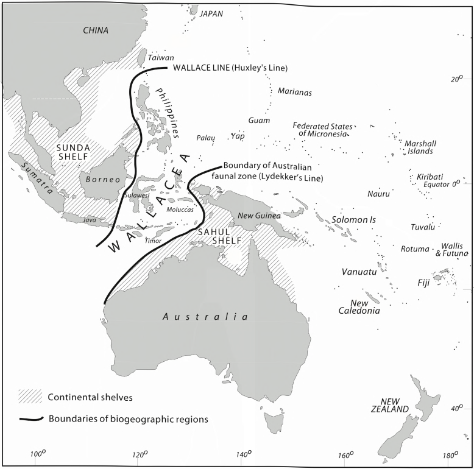

**Map 5:** Major zoogeographical boundaries in Island Southeast Asia

These faunal regions reflect geomorphological boundaries. The islands west of Wallace’s Line lie on the Sunda Shelf, a shallow continental shelf that was dry land at various times during the ice ages. As a consequence, the western islands of the Indo-Malaysian Archipelago share a similar mammal fauna with the Southeast Asian mainland and, to a lesser extent, with the Philippines and Taiwan. However, a deep trench separates Bali from Lombok, and few Asian mammal species were able to cross this. Similarly, during parts of the ice ages Australia and New Guinea formed a single land mass, Sahul (also known as Greater Australia or Meganesia), but were always separated from the Moluccas and Timor by deep water. Also part of Sahul were the Aru Islands southwest of New Guinea, but not the Kei Islands. Off the Bird’s Head, the West Papuan islands of Batanta, Gebe, Waigeo, Salawati and Misool (Mysol) were included, as were the islands of Cenderawasih Bay (Biak, Yapen, Numfoor) and the islands of the north coast shelf (Kairiru, Manam, Karkar, Bagabag). At the south end of New Guinea the D’Entrecasteaux Group, Louisiade Archipelago, Woodlark Island and the Trobriands were all part of the mainland. However, New Britain, New Ireland, the Solomons and the Admiralties were still separated from the New Guinea mainland and each other.

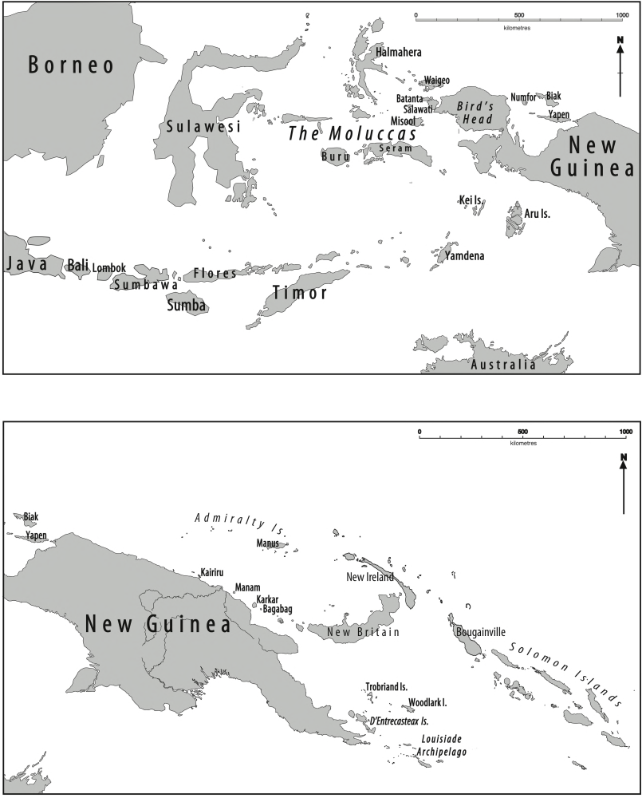

**Map 6:** Island Southeast Asia and Northwest Melanesia: island names

Robert Blust (1982, 2002, 2009a) has demonstrated the relevance of the Wallace Line to the subgrouping of Austronesian languages. In the most generally accepted subgrouping of Austronesian languages, all the Austronesian languages of New Guinea fall into a lower order group, namely Eastern Malayo-Polynesian. Blust writes

> Since placental mammals are not native to areas east of the Wallace Line, PAN and PMP must have been spoken west of that boundary. In crossing the Wallace Line [Austronesian] speakers would have encountered marsupials for the first time. If this happened through separate migrations into eastern Indonesia and the western Pacific there would be no basis for expecting that the terms for marsupial mammals would be cognate, since they would have been independently invented (or borrowed) at different times and in different places. As it happens, however, many languages of eastern Indonesia and the Pacific reflect *kandoRa ‘cuscus’ and *mansar/manser ‘bandicoot/marsupial rat’ which could not have been present in PAN or PMP.

> … it is simplest to attribute these innovations to a single speech community that was ancestral to the [Central Malayo-Polynesian, South Halmahera-West New Guinea and Oceanic] languages (2009a: 715-716).

Further significant zoogeographical boundaries occur within Oceania. As one travels from the New Guinea mainland to the Bismarck Archipelago, then east down the main Solomons chain and on into Remote Oceania, the land masses become smaller and the island groups further apart, and the faunal range declines markedly. Relatively few species of terrestrial mammals are widely distributed across Oceania. A good many taxa are restricted to New Guinea or to New Guinea, New Britain and New Ireland.

Reptiles and amphibians are not subject to the same geographical division. Terms for both crocodile and turtle occur on both sides of the Wallace Line and are reconstructable to PAn. Crocodiles were formerly present in Taiwan (see footnote on p.251), and their present breeding range extends from south-west India and the Philippines to the Santa Cruz group. Lizards and snakes are capable of swimming short distances, and are readily transportable on floating logs or rafts of vegetation, but the number of species shrinks as land masses decline in size and island groups become more widely scattered.

In the most generally accepted subgrouping of Austronesian languages, all the Austronesian languages of New Guinea fall into a lower order group, namely Eastern Malayo-Polynesian. It follows that for kinds of mammals found only in New Guinea we will not find a Proto Austronesian (PAn) or Proto Malayo-Polynesian (PMP) reconstruction.

The mammals known to POc speakers may be divided into those indigenous to the Bismarck Archipelago[^2]: and perhaps the north coast of New Guinea and those that humans brought to this region from island southeast Asia, namely the pig and dog and certain rat species.

## 2. Indigenous terrestrial mammals

### 2.1. Introduction

The indigenous mammal groups of Melanesia recorded in historic times are listed by Flannery (1995a: 13-15). The main island of New Guinea has one tree kangaroo genus and four genera of wallabies. It has several species of bandicoot and a large variety of possums, including cuscuses, pygmy possums, ringtail possums and gliders. It has two genera of spiny ant-eaters (monotremes). A less well known family is the Dasyuridae (formerly known as *Phascogale*), a family to which Tasmanian devils belong. The New Guinea dasyurids consist of quolls and antechinuses. The Bismarcks have only one bandicoot, one wallaby, and two species of phalanger. The Solomons have one phalanger. Murids and bats are represented by many different genera throughout New Guinea, the Bismarcks and the Solomons. In Vanuatu, New Caledonia, Fiji, Polynesia and Micronesia, the only native terrestrial mammals are bats. The range of a few indigenous mammals has been extended by human introductions.

### 2.2. Macropodidae

#### 2.2.1. Wallabies (Genera *Dorcopsis*, *Dorcopsulus*, *Macropus*, *Thylogale*)

Four genera of wallabies occur in the New Guinea area. *Dorcopsis* is a genus of small rainforest wallabies with an extensive range round the perimeter of New Guinea. One species, the black dorcopsis, is common on mountainous Goodenough Island in the D’Entrecasteaux group. A second genus, *Dorcopsulus*, the smallest of all the Macropodids, lives in mountain forests. A third genus, *Macropus*, the large sandy or agile wallaby, is primarily a savanna woodland animal of the south-eastern New Guinea mainland, but is also found on many of the Trobriand and D’Entrecasteaux islands and around Merauke in West Papua. It is hunted by many coastal people, an activity no doubt contributing to its somewhat erratic distribution. Flannery (1995a:82) mentions several reports of a large wallaby, possibly *Macropus agilis*, from southern New Ireland, which he has so far been unable to verify. The fourth genus, *Thylogale*, is the small scrub wallaby or pademelon. Its range includes the lowlands of northern New Guinea as far west as Jayapura, the hills round Port Moresby, the Huon Peninsula, New Britain and New Ireland. Bali-Vitu, spoken off the north-west coast of New Britain, has a term for wallaby. Lapita sites in the Arawe Islands, off the south-west coast of New Britain, have yielded bones of *Thylogale browni* as well as the cuscus *Phalanger orientalis* and the flightless cassowary, all introduced species.

One wallaby species is found on the islands west of the Bird’s Head, and others on Aru and on Kei. No wallabies are present in the Solomons or the Admiralties group. Although wallabies are now absent from the St Matthias group, bones of wallabies and a cuscus (*Spilocuscus maculatus*) have been recovered from Lapita middens excavated from the low flat coral island of Eloaue south-east of the high island of Mussau (Green 1979:37). Flannery and White state that the northern pademelon, *Thylogale browni*, was introduced into New Ireland some 7000 years ago, and that animals were possibly carried from there to the St Matthias group, although the species never became established there (Flannery 1995a:83).

The general pattern seems to be that different species adapt to particular areas, and are restricted to those areas. Although it may happen that two or three species are found within the territory familiar to a single language community, sources for each language usually give only one term for wallaby and it is likely that this is the generic.

A PWOc term for wallaby, *wakin, is well supported, with reflexes in North New Guinea, Papuan Tip and Meso-Melanesian languages. If terms in two non-Oceanic languages spoken on the West Papuan coast are cognate, then *wakin is reconstructable to PEMP and POc. The non-Oceanic terms, from Smits and Voorhoeve (1992:241), are glossed ‘kangaroo’, but the reference must be to small macropod species, popularly known as wallabies, as the larger species known as kangaroos are absent from New Guinea.

| **PEMP** |  | *wakin | ‘wallaby’ |
| --- | --- | --- | --- |
| SHWNG | Dusner | *waen* | ‘kangaroo’ (wallaby) |
| SHWNG | Mor | *uʔana* | ‘kangaroo’ (wallaby) |
| **POc** |  | *wakin | ‘wallaby’ |
| NNG | Lukep | *ok* | ‘wallaby’ |
| NNG | Mangap | *wok* | ‘wallaby’ |
| NNG | Bing | *woy* | ‘wallaby’ |
| NNG | Bilibil | *wei* | ‘wallaby’ |
| NNG | Gedaged | *woi* | ‘kangaroo (generic), incl. *Macropus*, *Dorcopsis*’ |
| PT | Kilivila | *waila* | ‘wallaby’ |
| PT | Iduna | *waɣi(tuli)* | ‘large grey wallaby’ |
| PT | Gabadi | *vai(aru)* | ‘wallaby, *Macropus agilis*’ |
| PT | Hula | *waɣi* | ‘wallaby, *Macropus agilis*’ |
| MM | Sursurunga | *wak* | ‘wallaby, includes Agile Wallaby, Forest Wallaby’ |
| MM | Konomala | *uakin* | ‘wallaby’ |
| MM | Minigir | *okin* | ‘wallaby’ |
| MM | Tolai | *okin* | ‘wallaby’ |
| MM | Tolai (Nodup) | *okini* | ‘wallaby’ |
| MM | Label | *uakin* | ‘wallaby’ |
| MM | Siar | *uakin* | ‘wallaby’ |

Several additional Papuan Tip terms support a PPT reconstruction *wagita ‘wallaby’ These appear to be compounds derived from *wakin + *ta(u), the second element possibly from POc/PPT *tau ‘person, body’.

| **PPT** |  | *wagita | ‘wallaby’ |
| --- | --- | --- | --- |
| PT | Diodio | *vayita* | ‘wallaby’ |
| PT | Bwaidoga | *vaɣita* | ‘wallaby, Agile wallaby’ |
| PT | Molima | *wagilita* | ‘bandicoot-like animal that eats coconuts’ |
| PT | Iamalele | *vagitau* | ‘opossum’ |

Agreements between NNG and PT languages point to a PNGOc term, *makan. Reflexes in PT languages predictably add a final *-i*. Retention of final *n plus the added vowel is unexpected in Motu and Magori, and suggests borrowing from a SE Papuan source, perhaps a dialect of Suau. At least two Central Papuan languages use reflexes of *makan ‘wallaby’ as a generic for ‘fish’. Ross (1994a: 422) uses the example of the two Sinaugoro dialects, one inland (Taboro), the other coastal (Balawaia), to suggest that the term was in some places generalised to cover protein food, and then restricted in some coastal languages to the main protein food available, namely fish.

| **PNGOc** |  | *makan | ‘wallaby, *Macropus agilis*’ |
| --- | --- | --- | --- |
| NNG | Dami | *maga* | ‘wallaby’ |
| NNG | Tumleo | *magə* | ‘wallaby’ |
| PT | Magori | *magani* | ‘wallaby, *Macropus agilis*’ |
| PT | Hula | *mani* | ‘wallaby’ |
| PT | Tawala | *makani* | ‘wallaby type’ |
| PT | Taboro | *maɣani* | ‘wallaby’ |
| PT | Balawaia | *maɣani* | ‘fish’ |
| PT | Motu | *maɣani* | ‘wallaby, *Macropus agilis*’ |
| PT | West Mekeo | *maka* | ‘fish’ |
| PT | Mekeo | *maʔi* | ‘wallaby, *Macropus agilis*’ |

cf. also:

| NNG | Matukar | *maku(sik)* | ‘wallaby’ (*-sik* perhaps from POc *siki ‘small’) |
| --- | --- | --- | --- |
| NNG | Kairiru | *meik* | ‘wallaby’ |
| NNG | Ali | *meik* | ‘wallaby’ |
| PT | Kuni | *mau* | ‘wallaby, *Macropus agilis*’ |

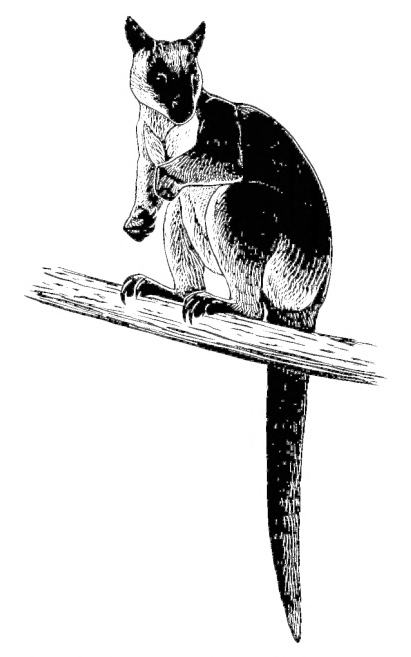

**Figure 5.1:** *Dendrolagus dorianus*, Doria’s tree kangaroo

#### 2.2.2. Tree kangaroos (Genus *Dendrolagus*)

To date, tree kangaroos are known outside the New Guinea mainland only on Umboi (presumably carried by humans from the nearby Huon Gulf area), Yapen and Salawati and Cape York, Australia (Van Deusen 1972:713, Flannery 1995a: 126-143). There is no record of their existence in the Admiralties or the Solomons, although we have a term for tree kangaroo from Sursurunga, New Ireland, and another from Kaulong, New Britain, presumably because people there are aware that they exist elsewhere.

Fewer than twenty terms for *Dendrolagus* have been collected in total, all bar one from North New Guinea, the odd one out being Meso-Melanesian: Sursurunga *atal* ‘wallaby, includes Matschie’s tree kangaroo’. Of the NNG terms, one is from New Britain (Kaulong *elan* ‘possum, also tree wallaby’), two are from a Schouten Chain language on the north coast (Sissano *nep* and *ʔapar*, both apparently meaning ‘tree kangaroo’) and one is from Bing, a Vitiaz Strait language north of the Huon Peninsula (*dagyiebiy* ‘tree kangaroo’). The remainder are from Huon Peninsula languages. No reconstructions are possible from these data other than a single low level term, Proto Buang *kekuŋ.

### 2.3. Cuscuses (Phalangeridae)

The phalangerids include the cuscuses of the New Guinea region and the brushtail possums of Australia. They are large arboreal herbivores. Several species of cuscus are present in mainland New Guinea and in the D’Entrecasteaux, Louisiade and Trobriand Islands. Phalangers are common in the islands immediately to the west and southwest of New Guinea, including Sulawesi, Timor, Ambon, Seram, Burn and Kei. Groves (1984) notes that Ambon and Seram have a distinct variety of *Phalanger orientalis*, and concludes that it got there without human intervention.

In prehistoric times certain species were translocated by humans to Island Melanesia and the Moluccas. New Britain, New Ireland and the Solomons each have an introduced species. *Phalanger orientalis*, the northern common cuscus (aka grey cuscus) is an abundant lowland species native to New Guinea that about 20,000 years ago was taken to New Ireland, where it became an important prey species (Leavesley 2005). It was introduced to the Solomon Islands and also to Timor at some time in the last 7,000 years (Flannery and Wickler 1990, Glover 1986). A single species, *Spilocuscus maculatus*, is found in the Admiralties, including Manus, Wuvulu and Ninigo. It is commonly hunted on Manus.

There is a well supported POc reconstruction for ‘cuscus’, *(k,kʷ)adroRa. For a number of languages, sources give the gloss ‘possum’ to its reflexes (‘possum’ is often used loosely in Australian English to refer to any member of the superfamily Phalangeroidea), but this can only refer to a phalanger.

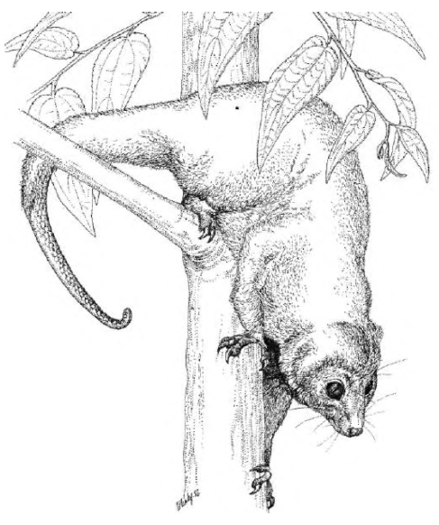

**Figure 5.2:** *Spilocuscus maculatus*, spotted cuscus

| **PCEMP** |  | *kandoRa | ‘cuscus’ (Blust 2002) |
| --- | --- | --- | --- |
| CMP | Watubela | *kadola* | ‘cuscus’ |
| **POc** |  | *(k,kʷ)adroRa | ‘phalanger, cuscus’ (Ross 1988: *kadroRa) |
| Adm | Mussau | *aroa* | ‘phalanger; cuscus’ (Smythe) |
| Adm | Bipi | *koxa* | ‘cuscus’ (metathesis) |
| Adm | Sori-Harengan | *ohay* | ‘cuscus’ (metathesis) |
| Adm | Penchal | *kotay* | ‘cuscus’ (metathesis) |
| Adm | Nauna | *kocay* | ‘cuscus’ (metathesis) |
| NNG | Mangap | *kendēre* | ‘opossum’ |
| NNG | Gedaged | *kodoɬ* | ‘k.o. phalanger with tan or greyish fur’ |
| NNG | Manam | *ʔodora* | ‘cuscus’ |
| PT | Dobu | *kʷadoiya* | ‘possum’ |
| PT | Kilivila | *kʷadoya* | ‘cuscus’ |
| PT | Muyuw | *kʷadoy* | ‘cuscus, possum’ |
| MM | Tabar | *adora* | ‘cuscus’ |
| MM | Lungga | *ɣadora* | ‘possum’ |
| MM | Simbo | *ɣadora* | ‘possum’ |
| MM | Maringe | *kadara* | ‘possum’ |

The following Southeast Solomonic terms reflect *kadora, with *-r-* for expected *-l-*. This is consistent with borrowing from Meso-Melanesian neighbours in the western Solomons.

| SES | Gela | *kadora* | ‘cuscus’ |
| --- | --- | --- | --- |
| SES | West Guadalcanal | *kadora* | ‘cuscus’ |
| SES | Talise | *kadora* | ‘cuscus’ |
| SES | Malango | *kadora* | ‘cuscus’ |

A second reconstruction is more weakly supported. It is well represented in the Cristobal-Malaitan branch of SE Solomonic but otherwise is reflected only in Gela, where the reflex refers to a juvenile cuscus, and in one Papuan Tip language.

| **POc** |  | *pu(dr,d,j)(o,u) | ‘species of possum or cuscus’ |
| --- | --- | --- | --- |
| PT | Suau | *hudu* | ‘striped possum’ (Flannery 1995: 203) |
| SES | Gela | *vuto* | ‘a young cuscus’ |
| SES | Owa | *futu* | ‘possum’ |
| SES | ’Are’are | *huto* | ‘possum’ |
| SES | Kahua | *huto* | ‘cuscus’ |
| SES | Longgu | *vuto* | ‘cuscus’ |
| SES | Lau | *futo* | ‘cuscus’ |
| SES | To’aba’ita | *futa* | ‘cuscus’ |
| SES | Sa’a | *huto* | ‘cuscus, phalanger’ |
| SES | Arosi | *huto* | ‘cuscus’ |

### 2.4. Other possum families (Acrobatidae, Burramyidae, Petauridae, Pseudocheiridae)

Besides the cuscuses, four other families within the super-family Phalangeroidea are represented in New Guinea. They include little feather-tailed possums (Acrobatidae), pygmy possums (Burramyidae), sugar gliders, striped possums and long-fingered striped trioks (all Petauridae) and ringtail possums (Pseudocheiridae). The Acrobatidae and Burramyidae are restricted to the Australian-New Guinea land mass. Sugar gliders are also found in the D’Entrecasteaux, Louisiade and Trobriand Islands and New Britain, and outside the Oceanic region on Halmahera, Kei and Aru. They are absent from New Ireland, the Solomons and the Admiralties. The Pseudocheiridae are poor dispersers who prefer montane forests, and are confined to New Guinea and a few of the larger islands off the coast of western New Guinea. A PNGOc term for ‘sugar glider’ is supported by probable cognates shared by several Papuan Tip languages and at least one North New Guinea language. However, reflexes show a number of irregularities, and it is necessary to reconstruct doublets.

| **PNGOc** |  | *si(r,R)(a,e)si(r,R)(a,e), *di(r,R)(a,e)di(r,R)(a,e) | ‘*Petaurus breviceps*, sugar glider’ |
| --- | --- | --- | --- |
| NNG | Gedaged | *saɬesaɬe* | ‘sugar glider, *Petaurus breviceps*’ (vowel metathesis) |
| NNG | Riwo | *siɬesiɬe* | ‘k.o. marsupial’ |
| PT | Molima | *selasela* | ‘sugar glider’ |
| PT | Iduna | *selasela* | ‘flying squirrel, sugar glider’ |
| PT | Tawala | *selasela* | ‘sugar glider’ |
| PT | Wedau | *sira-sira* | ‘squirrel’ (sugar glider) |
| PT | Lala | *dilodilo* | ‘glider phalanger’ (*-o* unexpected) |
| PT | Motu | *diledile* | ‘sugar glider, *Petaurus breviceps*’ |

cf. also:

| PT | Gapapaiwa | *surasura* | ‘flying squirrel’ |
| --- | --- | --- | --- |
| MM | Tolai | *diradira* | ‘flying squirrel’ (*d-* for †*∅*) |

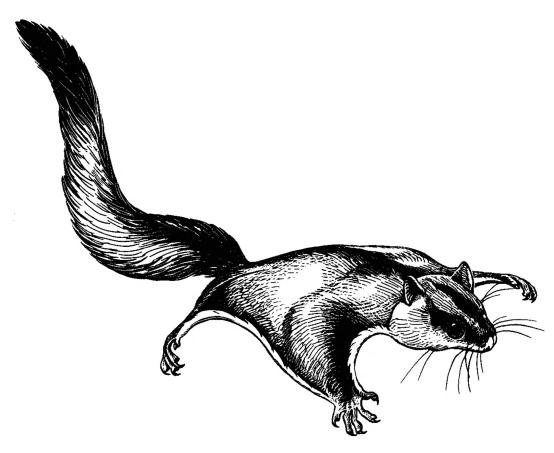

**Figure 5.3:** *Petaurus breviceps*, sugar glider

### 2.5. Bandicoots (Peroryctidae)

New Guinea is home to several genera of the family Peroryctidae, the bandicoots. They include *Echymipera* (common or spiny bandicoot, long-nosed bandicoot), *Peroryctes* (giant bandicoot, Raffray’s bandicoot), and *Microperoryctes* (mouse bandicoot, striped bandicoot). The mouse bandicoot is found only in the west of West Papua but the other genera are distributed widely on mainland New Guinea. Bandicoots are not present in the Solomons. Spriggs (1997a: 54) writes that at Pamwak, in Manus, bandicoots appear suddenly in the archaeological record at about 13,000 BP and quickly become dominant in the faunal record. This suggests human introduction. To the west of New Guinea, outside the region occupied by speakers of Oceanic languages, bandicoot species are present on Seram, Yapen, Waigeo, Kei and Aru. Compilers of wordlists are often unfamiliar with bandicoots, describing them as ‘large bush rats’, ‘marsupial rats’ or similar.

A POc term for ‘bandicoot’, *mʷajar, is well supported. There are reflexes in the Admiralties, North New Guinea, Papuan Tip and Meso-Melanesian subgroups referring to the bandicoot, and probable reflexes in Ponapean and certain Fijian dialects with change of referent. External cognates are found in several CEMP languages of the Moluccas and islands to the south of the Bird’s Head of New Guinea, where the reference is often to cuscus rather than bandicoot.

[figure not shown]

**Figure 5.4:** *Microperoryctes longicauda*, long-tailed bandicoot

| **PCEMP** |  | *mansar | ‘bandicoot, marsupial rat’ (Blust 1982, 2002) |
| --- | --- | --- | --- |
| CMP | Ujir (Aru Is.) | *meday* | ‘cuscus’ (Antoinette Schapper, pers. comm.) |
| CMP | Ambelau | *mate* | ‘bandicoot, marsupial rat’ |
| CMP | Kei | *medar* | ‘cuscus’ |
| CMP | Yamdena | *mande* | ‘cuscus’ |
| **POc** |  | *mʷajar | ‘bandicoot’ |
| Adm | Lou | *mʷas* | ‘bandicoot, marsupial rat’ |
| Adm | Nauna | *mʷac* | ‘bandicoot, marsupial rat’ |
| NNG | Mangap | *mōzo* | ‘bandicoot’ |
| NNG | Wogeo | *mʷaja* | ‘cuscus’ |
| NNG | Ali | *maic* | ‘bandicoot’ |
| PT | Sudest | *mʷaja-mʷaja* | ‘bandicoot’ |
| PT | Taboro | *moda* | ‘bandicoot’ |
| PT | Motu | *mada* | ‘k.o. bandicoot’ |
| MM | Meramera | *maso* | ‘bandicoot’ |
| MM | Tolai | *mā(ŋ)* | ‘bandicoot’ |
| MM | Ramoaaina | *ma(n)* | ‘bandicoot’ |
| Mic | Ponapean | *(keli)mʷet* | ‘k.o. small bat’ (*keli-* ‘prefix signifying danger, connection with spirit world’; Blust 2001b) |
| Fij | Namosi | *ŋʷaða* | ‘k.o. large rat’ (Blust 1993) |

The following are probably borrowed from a pre-Oceanic or early Oceanic language (Ross 1988:21):

| NNG | Megiar | *madar* | ‘bandicoot’ |
| --- | --- | --- | --- |
| NNG | Takia | *madar* | ‘bandicoot’ |
| NNG | Yabem | *mojaŋ* | ‘marsupial rat, cuscus, possum, tree kangaroo’ |
| NNG | Mapos Buang | *masaŋ* | ‘possum, *Pseudocheirus corinnae*, yellow-green ring-tailed possum’ |

### 2.6. Marsupial carnivores (Dasyuridae)

The Dasyuridae are a family of carnivorous and insectivorous marsupial rodents, including various antechinus species and quolls and, most famously, the Tasmanian devil. Five genera of dasyurids are unique to New Guinea and three genera are common to New Guinea and Australia. Most dasyurids are small, weighing between 100-500 grams, although quolls of the New Guinea rainforest may exceed half a kilogram in weight (Flannery 1995: 83). Dasyurids may be either diurnal or nocturnal, and some antechinus species are partly arboreal. Many species are found in rainforest, often at middle to high altitudes. Few members of the family have been recorded from coastal Austronesian-speaking areas, although one antechinus is found on Normanby in the D’Entrecasteaux Group, and other dasyurids have been recorded from the Aru Islands. Flannery (1995:84) comments that quolls will enter villages to catch rats, and are respected as fierce predators by most New Guineans familiar with them, who show great caution when handling them.

No Oceanic terms for dasyurids have been recorded. It is likely that compilers of wordlists have generally not been familiar with dasyurids as such, and in some cases have referred to them by a term such as ‘small marsupial rodent’.

### 2.7. Echidnas (Tachyglossidae)

Monotremes are represented in New Guinea by two genera of echidna: *Tachyglossus* (short-beaked echidna) and *Zaglossus* (long-beaked echidna). Both are regarded as rare. Flannery (1995: 67) suggests that hunting pressure has severely reduced their numbers. Very little is known about the distribution and natural history of *Tachyglossus*, but it has been recorded in the Markham valley and around Port Moresby, and from the island of Salawati off the Bird’s Head. *Zaglossus* has also been reported from both the western and eastern extremities of New Guinea, but is found only where population densities are low. A term for the echidna is present in only two languages in our sample (Sinaugoro *modagini* ‘anteater’ (cf. *moda* ‘bandicoot’) and Motu *miɣu* ‘short-beaked echidna’) and no reconstructions are possible.

### 2.8. Rats (Muridae)

Rats were a significant source of protein for many Oceanic communities in prehistoric times. The diversity of rat species diminishes sharply as one moves from New Guinea to the Bismarcks and Solomons. In New Guinea the murid fauna is ‘abundant and diverse, and for the size of the land mass, one of the most species-rich found anywhere on earth’ (Flannery 1995: 231). There are some 27 genera there, including Hydromys, Leptomys, Mallomys, Melomys, Pogonomys, Uromys, Rattus and Stenomys, although only a subset of these are present in any one region. Most New Guinea area species are endemic.

Nine murid species are endemic to the Solomons, including two that are extinct. Three species of Solomys and one of Uromys have evolved into large or very large arboreal rats, which are probably the evolutionary counterparts of the possums of Sahul. However, single islands in the Solomons seldom have more than two or three species. No rat species were present in Remote Oceania before the advent of humans.

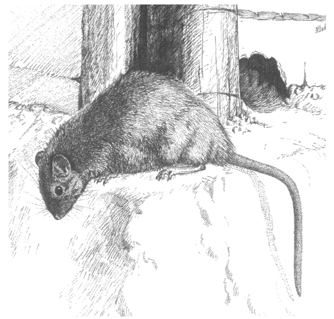

**Figure 5.5:** *Rattus exulans*, rat

*Rattus praetor*, the spiny rat, considerably larger than exulans, is native to New Guinea, where it is widespread north and south of the central ranges as far east as the Sepik-Ramu basin. It also occurs on offshore islands in the Bismarck Archipelago where it appears in archaeological assemblages dated to at least 13,000 years ago (White, Clark and Bedford 2000) and in the Solomon Islands, where its introduction is probably of similar antiquity. *Rattus praetor* is now extinct in Remote Oceania but occurs in archaeological sites in Vanuatu and Fiji, though not in Polynesia or Micronesia.

A third commensal species, *Rattus tanezumi*, the Asian house rat, has a narrow distribution in Oceania, being securely attested only in archaeological sites in the Caroline Islands and the northern Marianas, dated to within the last 1,000 years. *Rattus tanezumi* is native to South Asia and Southeast Asia and its Oceanic distribution is consistent with transport direct from Island Southeast Asia to the Carolines, rather than via Melanesia.

Sources for Oceanic language seldom give precise identifications for rat terms. Glosses tend to be of the order of ‘bush rat’ or simply ‘kind of rat’, glosses which fail to capture genuine taxa in the language. One investigator (Futscher 1959) recorded at least 10 terms for kinds of rat in Tolai but the glosses simply say ‘mouse’.

POc *kasupe, continuing PEMP *kanzupay, has reflexes applied to one or more species of the genus *Rattus*, rats living in and around human settlements. Reflexes in Cristobal-Malaitan and Vanuatu languages preserve initial syllable *-a-. Those in Western Oceanic and Guadalcanal languages and in Western Fijian show initial *u-*. These may represent several independent cases where the first vowel assimilated to the following *u*. However, the assimilation is so widespread it is reasonable to reconstruct a POc doublet, *kusupe.

| **PCEMP** |  | *kanzupay | ‘rat’ (Blust 1993) |
| --- | --- | --- | --- |
| **POc** |  | *kasupe, *kusupe | ‘rat taxon, probably *Rattus exulans* and possibly other small commensal sp. or spp.’ |
| Adm | Drehet | *(n)osop* | ‘marmot’ (sic; cf. *pʷek* ‘rat’) |
| Adm | Seimat | *usuh* | ‘k.o. rat’ |
| NNG | Malai | *uzuv* | ‘rat’ |
| NNG | Mangap | *kuzi* | ‘rat/mouse’ |
| NNG | Malasanga | *kui* | ‘rat’ |
| NNG | Mindiri | *kusue* | ‘rat’ |
| NNG | Wogeo | *kusive* | ‘rat’ |
| NNG | Ulau-Suain | *isup* | ‘bandicoot’ |
| PT | Lala | *uduve* | ‘rat’ |
| PT | Ouma | *ureve* | ‘rat’ |
| MM | Tolai | *kaupa* | ‘rat, mouse, Mus browni’ |
| MM | Vitu | *kuðuve, kuvuðe* | ‘rat’ (metathesis) |
| MM | Bali | *kuzuveke* | ‘rat’ (final *-ke* unexpected)[^3] |
| MM | Bola | *kuruve* | ‘rat’ |
| MM | Madak | *kisap* | ‘rat’ |
| MM | Siar | *kusup* | ‘rat’ |
| MM | Kandas | *kusupu* | ‘rat’ |
| MM | Teop | *kuho* | ‘rat’ |
| MM | Varisi | *kuzu* | ‘rat’ |
| MM | Ririo | *kuj* | ‘rat’ |
| SES | West Guadalcanal | *ɣusuve* | ‘rat’ |
| SES | Talise | *ɣusuve* | ‘rat’ |
| SES | Malango | *husuve* | ‘rat’ |
| SES | Lau | *ʔasufe* | ‘rat’ |
| SES | Kwaio | *ʔasufe* | ‘rat’ |
| SES | ’Are’are | *ʔasuhe* | ‘rat’ |
| SES | Sa’a | *ʔasuhe* | ‘rat’ |
| SES | Arosi | *kasuhe* | ‘rat’ |
| NCV | Mota | *ɣasuwe* | ‘rat’ |
| NCV | Mwotlap | *(na)ɣhōw* | ‘rat, *Rattus rattus*’ |
| NCV | Paamese | *asue* | ‘rat’ |
| SV | North Tanna | *kahap* | ‘mouse, rat’ |
| SV | Lenakel | *kahau* | ‘rat’ |
| SV | Kwamera | *(i)esukʷ* | ‘mouse, rat’ |
| Fij | Wayan | *kuðuve* | ‘generic for rats and mice’ |

Reflexes of the root PAn *-labaw ‘rat’ occur alone or in combination with a preposed CV-formative in various daughter languages, yielding a number of related terms including PAn *kulabaw and PMP *balabaw (Blust 2002:107).

As an independent form *labaw is traceable back to PMP, with Oceanic reflexes from the Te Motu group and, less certainly, the Malakula languages of Vanuatu.

| **PMP** |  | *labaw | ‘rat, mouse’ |
| --- | --- | --- | --- |
| WMP | Kagayanen | *ambaw* | ‘mouse, rat’ |
| CMP | Manggarai | *lavo* | ‘rat’ |
| CMP | Rotinese | *lafo* | ‘mouse, rat’ |
| **POc** |  | *la(b,p)(o,u) | ‘rat taxon’ |
| TM | Äiwoo | *lapū* | ‘rat’ (Tryon and Hackman 1983: 190; Wurm 1969: 69) |
| TM | Natügu | *lopu* | ‘rat’ (Wurm 1969: 69) |
| TM | Tanibili | *no-uvo* | (Tryon & Hackman) |
| Pn | Pileni | *lepū* | (probable borrowing from TM) |

cf. also: the following terms for ‘rat’ from Malakula languages:

| NCV | Neve’ei | *ne-labut* | ‘rat taxon’ |
| --- | --- | --- | --- |
| NCV | Nāti | *ne-lemput* | ‘rat taxon’ |
| NCV | Naman | *labët* | ‘rat taxon’ |
| NCV | Southwest Bay | *lambut* | ‘rat taxon’ |

The latter forms exhibit a final *-t* which is unexpected in comparison with PMP *labaw. Tagbanawa (Kalamian), a Philippines language, has a similar word *laput* ‘rat’ but this is likely to be an accidental resemblance.

PMP *bualabaw has probable Oceanic reflexes in Admiralty and NNG languages. The expected POc form is *bʷalapo or *pʷalapo, and Bing *palāf* supports the latter. However, the final vowels of the Admiralties forms are unexplained. The Titan and Aua forms also show irregular loss of *-p-.

| **PMP** |  | *bualabaw | ‘rat, mouse’ (ACD: *balabaw) |
| --- | --- | --- | --- |
| WMP | Malagasy | *vualavu* | ‘rat’ (Blust 1972a) |
| WMP | Ngaju Dayak | *belawaw* | ‘rat’ (Blust 1972a) |
| WMP | Uma | *flulehuʔ* | ‘mouse, rat’ (Tryon 1995: 03.630) |
| WMP | Buginese | *balawo* | ‘mouse, rat’ |
| CMP | Konjo | *balaho* | ‘mouse, rat’ (Tryon 1995: 03.630) |
| CMP | Buru | *blafe(n)* | ‘marsupial rat’ (Grimes, pers. comm) |
| **POc** |  | *pʷalapo | ‘rat taxon’ |
| Adm | Titan | *buléy* | ‘rat’ (Blust 1996:43) |
| Adm | Wuvulu | *balafa(i)* | ‘rat’ (Blust 1993, 1996:43) |
| Adm | Aua | *balā* | ‘rat’ (Blust 1993) |
| NNG | Bing | *palāf* | ‘bush rat with very strong teeth’ |

PAn *kulabaw ‘rat, mouse’, with reflexes in Taiwan (Paiwan *kulavaw* ‘mouse, rat’, Rukai *kolabaw* ‘rat in the fields’) as well as in MP languages is reconstructed by Blust (2002). A probable Oceanic reflex has been recorded in Bauan Fijian: *kalavo* ‘rat’. Amber (SHWNG) agrees with Bauan in having initial ka rather than ku, pointing to PEMP *kalabaw, POc *kalapo.

| **PAn** |  | *kulabaw | ‘rat, mouse’ (Blust 2002) |
| --- | --- | --- | --- |
| **PEMP** |  | *kalabaw | ‘rat, mouse’ |
| SHWNG | Amber | *kalubu* | ‘mouse’ (Smits) |
| **POc** |  | *kalapo | ‘rat taxon’ |
| Fij | Bauan | *kalavo* | ‘rat (*Rattus* spp.)’ |

Two distinct cognate sets are widespread in Polynesia. The terms are simply glossed ‘rat’ in the sources, unless otherwise noted, but the proto-forms must all have referred to *Rattus exulans*.

| **PPn** |  | *kumā | ‘rat’ (pollex) |
| --- | --- | --- | --- |
| Pn | Tongan | *kumā* | ‘rat’ |
| Pn | Niuean | *kumā* | ‘rat’ |
| Pn | East Uvean | *kumā* | ‘rat’ |
| Pn | Anutan | *kuma* | ‘rat’ |
| Pn | Tikopia | *kuma(ri)* | (final *-ri* unexpected) |
| Pn | Marquesan | *kuma-kuma* | ‘rat’ |

The second set is confined to Nuclear Polynesian languages.

| **PNPn** |  | *kimoa | ‘rat, *Rattus exulans*’ |
| --- | --- | --- | --- |
| Pn | Samoan | *ʔimoa* | ‘rat, *Rattus exulans*’ |
| Pn | Tuvalu | *kimoa* | ‘rat, *Rattus exulans*’ |
| Pn | Nukuoro | *kimoo* | ‘rat, *Rattus exulans*’ |
| Pn | Ifira-Mele | *kimoa* | ‘rat, *Rattus exulans*’ |
| Pn | Rennellese | *kimoa* | ‘rat, *Rattus exulans*’ |
| Pn | West Uvea | *kimoa* | ‘rat, *Rattus exulans*’ |

Lincoln (2007) points to terms for ‘rat’ in various PT languages from Milne Bay Province that do not correspond regularly to *kimoa but show more than a passing resemblance. The Milne Bay terms are from unpublished wordlists recorded by Pawley (1969).

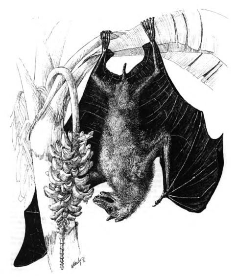

**Figure 5.6:** *Dobsonia moluccensis*, greater bare-backed bat

| PT | Oya’oya | *gimau* | ‘rat’ |
| --- | --- | --- | --- |
| PT | Logea | *gimʷau* | ‘rat’ |
| PT | Tubetube | *gimʷau* | ‘rat’ |
| PT | Saliba | *ɣimʷau* | ‘rat’ |
| PT | Gilagila | *gibʷau* | ‘rat’ |

The following reconstruction is attributable to Proto Western Oceanic on the basis of cognates in North New Guinea, New Ireland and NW Solomonic.

| **PWOc** |  | *kotu | ‘rat’ |
| --- | --- | --- | --- |
| NNG | Sio | *koto* | ‘rat’ |
| MM | Tabar | *kotu* | ‘rat’ |
| MM | Tangga | *kut* | ‘rat’ |
| MM | Hoava | *kutu* | ‘rat’ |
| MM | Marovo | *kutu* | ‘rat, common type’ (*kiitu vaka* ‘big rat that eats coconuts’; Hviding) |
| MM | Vangunu | *kutu* | ‘rat’ |

### 2.9. Bats (Order: Chiroptera, Suborders Megachiroptera, Microchiroptera)

Bats form a very large order consisting of two suborders and at least six families (Flannery 1995). The Megachiroptera include the fruit-sucking bats (flying foxes and fruit bats) and bats which feed on nectar and pollen. Figure 5.6 shows the greater bare-backed fruit bat, *Dobsonia moluccensis* (aka *D. mapna*). This species and others of the genus Dobsonia are widespread in New Guinea and Island Melanesia, as far east as the Solomons, as are other members of the family Pteropodidae (fruit-bats). The Microchiroptera include tube-nosed bats, sheathtail bats, horseshoe bats and leaf-nosed bats, typically insectivorous, although at least one genus preys on small fish (Flannery 1995: 455). Several species of Microchiroptera are recently described, and revision of the genera is ongoing.

Reflexes of PMP *paniki ‘fruit bat, flying fox, *Pteropns* spp.’ occur in the Philippines and Indonesia, but have not been located in Oceanic languages. POc *bʷeka is a well supported reconstruction. It has reflexes denoting ‘fruit bat’ in most major subgroups of Oceanic, an exception being Papuan Tip. In NCV languages *bʷeka is generally lost but in a few languages the form is continued as the name for the barn owl, *Tyto alba*. For North New Guinea reflexes see under *mali-bʷeka below.

| **POc** |  | *bʷeka | ‘flying fox, large fruit bat’ |
| --- | --- | --- | --- |
| Adm | Drehet | *pʷek* | ‘rat’ |
| Adm | Titan | *pʷe* | ‘bat, flying fox’ |
| MM | Bali | *beɣa* | ‘flying fox’ |
| MM | Vitu | *beɣa* | ‘flying fox’ |
| MM | Nakanai | *beka* | ‘flying fox’ |
| MM | Meramera | *bea* | ‘flying fox’ |
| MM | Sursurunga | *bek* | ‘generic, fruit bat, flying fox’ |
| MM | Patpatar | *beka* | ‘flying fox’ |
| NCV | Araki | *peka* | ‘*Tyto alba*, barn owl’ |
| NCV | Tangoa | *beka* | ‘*Tyto alba*, barn owl’ |
| NCal | Nemi | *bʷek* | ‘flying fox’ |
| NCal | Jawe | *bʷek* | ‘bat, flying fox’ |
| Mic | Kosraean | *fak* | ‘bat’ |
| Mic | Mokilese | *pʷēk* | ‘bat’ |
| Mic | Ponapean | *pʷēk* | ‘bat’ |
| Fij | Wayan | *bekʷa* | ‘bat (generic)’ |
| Fij | Bauan | *beka* | ‘fruit bat’ |
| Pn | Niuean | *peka* | ‘flying fox, fruit bat’ |
| Pn | Tongan | *peka* | ‘bat, flying fox’ |
| Pn | Rennellese | *peka* | ‘flying fox: formerly important for teeth and food, and for the sport of snaring’ |
| Pn | Samoan | *peʔa* | ‘flying fox’ |
| Pn | Tikopia | *peka* | ‘fruit bat, both large and small’ |
| Pn | Hawaiian | *peʔa* | ‘bat’ |

A few Admiralties and North New Guinea languages reflect a complex form *mali-bʷeka. The etymology of *mali- is uncertain but it is most likely a modification of POc *manuk ‘bird, bat’.

| **POc** |  | *mali-bʷeka | ‘flying fox, large fruit bat’ |
| --- | --- | --- | --- |
| Adm | Nyindrou | *balimek* | ‘large fruit bat’ (metathesis of two foot-initial consonants) |
| Adm | Drehet | *pelemik* | ‘bat/flying fox’ |
| NNG | Vehes | *mɛbɛk* | ‘fruit bat’ |
| NNG | Mapos Buang | *malibək* | ‘large fruit bat, flying fox’ |

cf. also:

| Adm | Titan | *pálimet* | ‘flying fox, fruit-eating bat’ |
| --- | --- | --- | --- |

| **POc** |  | *mali-boŋi | ‘flying fox’ |
| --- | --- | --- | --- |
| SJ | Tarpia | *boni* | ‘bat’ (Smits and Voorhoeve 1992: 244) |
| NNG | Tami | *malimboŋ* | ‘flying fox’ |
| NNG | Wab | *malboŋ* | ‘flying fox’ |
| NNG | Bing | *malbaŋ-boŋ* | ‘flying fox (mid size)’ |
| NNG | Bing | *malboŋ* | ‘flying fox, fruit bat’ |
| NNG | Manam | *malaboŋ* | ‘flying fox’ |
| PT | Suau | *malibon* | ‘flying fox’ |
| PT | Molima | *niboi* | (unexpected loss of first syllable) |
| PT | Motu | *mariboi* | ‘large fruit bat, flying fox’ (for †*maiboi*) (Oram n.d.) |
| PT | Motu | *(sisi)boi* | ‘small bat’ (*sisi* ‘small’) |
| PT | Gabadi | *(manu)boʔi* | ‘flying fox’ (for †*maiboni*, possibly a folk etymology: *manu* < *manuk ‘bird’) |
| MM | Tiang | *mələbiŋ* | ‘flying fox’ |
| MM | Nalik | *məlbuŋ* | ‘flying fox’ |
| NCV | Mwotlap | *ilbʷōŋ* | (1) ‘a small dark bat’; (2) ‘Vanikoro swift’ (unexpected loss of initial nasal) |

cf. also: the following, which are glossed’flying fox’ and appear to reflect *mali + *eba or *oba.

| Adm | Mussau | *marieba* | ‘flying fox’ (*-r-* for †*-l-*) |
| --- | --- | --- | --- |
| PT | Ouma | *maiba* | ‘flying fox’ |
| PT | Balawaia | *maioba* | ‘flying fox’ |
| PT | Maopa | *maopa* | ‘flying fox’ |
| PT | Hula | *maopa* | ‘flying fox’ |

In many Oceanic languages small insectivorous bats (Microchiroptera) have a separate name from fruit bats. It is uncertain whether this was also the case in POc. In parts of Polynesia reflexes of *peka-peka are given both to a small bat and to a swift whose behaviour, form and habitat resemble superficially that of insectivorous, cave-dwelling bats. The Fijian languages have cognate reduplicated forms referring only to small cave bats. Reduplication is commonly used to show diminutives in some Oceanic languages (see also vol.3,50-51).

| **PCP** |  | *beka-beka | ‘small insectivorous, cave-dwelling bat’ |
| --- | --- | --- | --- |
| Fij | Wayan | *bekʷa-bekʷa* | ‘a small insectivorous cave-dwelling bat’ |
| Fij | Bauan | *beka-beka* | ‘insect-eating bat’ |
| **PPn** |  | *peka-peka | (1) ‘small bat’; (2) ‘white-rumped swiftlet’ |
| Pn | Niuean | *peka-peka* | ‘bird, white-rumped swiftlet, nests in caves’ |
| Pn | Tongan | *peke-peka* | ‘swallow’ |
| Pn | East Futunan | *peka-peka* | ‘small bat’ |
| Pn | East Uvean | *peka-peka* | ‘k.o. small swallow’ |
| Pn | Rennellese | *peka-peka* | ‘glossy swiftlet’ |
| Pn | Samoan | *peʔa-peʔa* | ‘white-rumped swiftlet’ |
| Pn | Māori | *peka-peka* | ‘bat’ |
| Pn | Hawaiian | *(ʔō)peʔa-peʔa* | ‘bat’ |

An unrelated Mwotlap term, *ilbʷōŋ* (*bʷōŋ* from POc *boŋi ‘night’) refers to the same two creatures, a small dark bat and a Vanikoro swift, a bird with wholly dark plumage (A. François, pers. comm.), while Kwamera (SV) has *kiri* ‘flying fox’ and *kiri-kapou* ‘glossy swiftlet’.

## 3. Introduced terrestrial mammals

### 3.1. Pigs (genus *Sus*, family Suidae)

Island Southeast Asia is the centre of genetic diversity of the genus *Sus*, containing six of the 10 generally recognised species: *S. verrucosus* (the Javan warty pig), *S. barbatus* (the bearded pig of Malaysia, Sumatra and Borneo with a subspecies in Palawan), *S. celebensis* (the Sulawesi warty pig), *S. cebifrons* (the Visayan warty pig), *S. philippensis* (the Philippines warty pig) and *Sus scrofa* (the common wild pig, endemic to Europe, North Africa, parts of Asia and parts of the Indo-Malaysian archipelago). No pig species is native to New Guinea or any part of Oceania.

Most pig species have never been domesticated. The most important exception is *Sus scrofa*, which was domesticated in the Middle East and in China around 10,000 years ago and subsequently introduced to many regions. A wild variety of this species, *Sus scrofa* vittatus, the banded pig, inhabits Sundaland from the Malay Peninsula to Sumatra, Java and Bali. It is also present east of Wallace’s Line on Sumbawa and Lombok, possibly due to human transportation.

Sus celebensis occurs domesticated only in Timor and Roti. Groves (1984) argues that its natural range is Sulawesi and offshore islands, and that its presence on Timor, Roti, Flores, Halmahera (and even more surprisingly, on Simalue, west of Sumatra) is the result of human agency. A similar conclusion, based on genetic evidence, is drawn by Larson et al. (2007). Groves (1984:3) suggests that the wild and domestic pigs of New Guinea are a cross between the banded pig and the Sulawesi warty pig.

Pigs, domesticated and wild, appear to have been part of the Austronesian world since PAn times. A number of terms associated with pigs and pig husbandry can be reconstructed for PAn and PMP. In his Austronesian Comparative Dictionary (1995), Blust writes that

> Although PAn *beRek evidently meant ‘domesticated pig’ PAn *babuy referred to pigs in general, with qualifications where needed.[^4]: In other words, the glosses of *babuy and *beRek were not perfectly complementary, but partially overlapping …. Reflexes of both *babuy and *beRek are found in Formosan and WMP, but only *babuy is reflected in CMP and only *beRek in Oceanic.

The history of the introduction of pigs into Oceania has been a matter of debate. Pig bones occur in early Lapita sites from the Bismarck Archipelago to the Reef Is. in the period 3300-3100 BP. A recent genetic study supports the view that although Lapita pigs reached Melanesia via Indonesia they ultimately stem from Vietnam or nearby parts of mainland Southeast Asia, rather than from Taiwan (Larson et al. 2007), but domestic pig bones dated to 4000 BP have been found in cultural deposits in the Philippines (Piper et al. 2009). Some archaeologists argue that the wild pigs of New Guinea are feral descendants of Lapita pigs. Others hold that pig teeth are present in New Guinea highland assemblages predating Lapita, although it has proved difficult to securely date these finds.

POc *boRok is continued in all the major subgroups of Near Oceania and in parts of Remote Oceania as far east as western Fiji. However, no reflexes are found in New Caledonia and the Loyalty Is., where pigs have been absent since initial settlement by Lapita peoples, or in eastern Fiji and Polynesia.

| **PAn** |  | *beRek | ‘domesticated pig’ (ACD) |
| --- | --- | --- | --- |
| **POc** |  | *boRok | ‘pig, Sus serofa’ |
| Adm | Seimat | *pou* | ‘pig, Sus serofa’ |
| Adm | Lou | *puo* | ‘pig, Sus serofa’ |
| Adm | Nyindrou | *bou* | ‘pig, Sus serofa’ |
| NNG | Takia | *bor* | ‘pig, Sus serofa’ |
| NNG | Manam | *boro* | ‘pig, Sus serofa’ |
| NNG | Yabem | *boʔ* | ‘pig, Sus serofa’ |
| NNG | Mumeng | *bʷok* | ‘pig, Sus serofa’ |
| PT | Tubetube | *buluka* | ‘pig, Sus serofa’ |
| PT | Kilivila | *bulukʷa* | ‘pig, Sus serofa’ |
| PT | Bwaidoga | *bulukʷa* | ‘pig, Sus serofa’ |
| PT | Gapapaiwa | *poro* | ‘pig, Sus serofa’ |
| PT | Wedau | *poro* | ‘pig, Sus serofa’ |
| MM | Bali | *boroko* | ‘pig, Sus serofa’ |
| MM | Tabar | *boro* | ‘pig, Sus serofa’ |
| MM | Nakanai | *bolo* | ‘pig, Sus serofa’ |
| MM | Tolai | *boro(i)* | ‘pig, Sus serofa’ |
| MM | Simbo | *boroɣo* | ‘pig, Sus serofa’ |
| SES | Gela | *bolo* | ‘pig, Sus serofa’ |
| SES | Tolo | *bolo* | ‘pig, Sus serofa’ |
| **PNCV** |  | *boe | ‘pig, male pig’ (final *-e* unexpected) |
| NCV | Mota | *pʷoe* | ‘pig, male pig, barrow pig’ |
| NCV | Kiai | *poe* | ‘pig, Sus serofa’ |
| NCV | Raga | *boe* | ‘pig, Sus serofa’ |
| NCV | Nokuku | *poe* | ‘pig, Sus serofa’ |
| Fij | Wayan | *gō* | ‘pig, Sus serofa’ |

Reflexes of *boRok in many Solomons languages are irregular. Irregular loss of *R is exhibited in this term in most Cristobal-Malaitan languages, e.g. Longgu *bo*, Sa’a *pō*, Santa Ana *bʷō*, some Guadalcanal languages, e.g. Ghari *bo*, and many NW Solomonic languages, e.g. Roviana *boko*. North Malaitan languages show unexpected *s* as the medial consonant, as in Fataleka *boso*, suggesting borrowing from Santa Isabel languages, which typically show the same replacement.

POc *boRok is not retained in Polynesian languages, being replaced by PPn *puaka. This appears to continue POc *b(o,u)kas(i), which has reflexes in PT, NCV and SV. Reflexes of both *boRok and *b(o,u)kas(i) persist in PT and NCV. It is not clear whether there was a meaning difference between the two terms.

| **POc** |  | *b(o,u)kas(i) | ‘pig’ |
| --- | --- | --- | --- |
| PT | Sudest | *voɣadi* | ‘wild pig that dogs can’t kill’ |
| PT | Dobu | *boʔas(a)* | ‘village pig’ |
| **PSOc** |  | *bukasi | ‘pig (generic), and probably by default male pig, boar’ (John Lynch, pers. comm.) |
| NCV | Mota | *puɣas* | ‘to rear with food, tame by feeding’ |
| NCV | Paamese | *vuasi* | ‘pig (generic)’ |
| NCV | Nguna | *(na-)pʷokasi* | ‘meat, flesh’ |
| SV | Lenakel | *pukas* | ‘pig’ |
| SV | Kwamera | *pukah* | ‘pig’ |
| SV | Anejom̃ | *pikaθ* | ‘pig’ |
| **PPn** |  | *puaka | ‘pig’ |
| Pn | Tongan | *puaka* | ‘pig’ |
| Pn | Samoan | *puaʔa* | ‘pig’ |
| Pn | Tikopia | *puaka* | ‘pig’ (archaic) |
| Pn | Hawaiian | *puaʔa* | ‘pig’ |

cf. also: The following are all Polynesian loans.

| PT | Saliba | *puaka* | ‘pig’ |
| --- | --- | --- | --- |
| PT | Magori | *uaka* | ‘pig’ |
| PT | Yoba | *uaʔa* | ‘pig’ |
| NCal | Nixumwak | *puaka* | ‘pig’ |
| NCal | Iaai | *buaka* | ‘pig’ |
| Fij | Bauan | *vuaka* | ‘pig’ |

Another term, *bʷasa, may have referred specifically to sows. This term has reflexes in NNG, PT, MM and SES.

| **POc** |  | *bʷasa | ‘pig, possibly sow’ |
| --- | --- | --- | --- |
| NNG | Bilibil | *bas* | ‘pig’ |
| PT | Ouma | *bura* | ‘pig’ |
| MM | Patpatar | *pes* | ‘female pig’ |
| SES | Gela | *baha* | ‘sow’ |
| SES | Lau | *gʷata* | ‘sow’ |
| SES | To’aba’ita | *gʷata(kʷala)* | ‘sow that has had young more than once’ (*kʷala* ‘bear young’) |
| SES | ’Are’are | *ata* | ‘sow’ (for †*pata*) |
| SES | Kwara’ae | *gʷat* | ‘pig’ (Tryon and Hackman 1983: 185) |

cf. also:

| SES | Arosi | *bʷa-bʷa* | ‘female (only of pigs)’ (zero for †*-t*) |
| --- | --- | --- | --- |
| SES | Sa’a | *pʷa-pʷa* | ‘female of an animal; lay eggs’ (zero for *†-t*) |

In NCV there is a widespread cognate set pointing to PNCV *bʷara-bʷara ‘female pig’.

| **PNCV** |  | *bʷarabʷara | ‘female pig’ (Clark 2009) |
| --- | --- | --- | --- |
| NCV | Uripiv | *bʷer-pʷer* | ‘pig (generic)’ |
| NCV | Lonwolwol | *ba-bar* | ‘female pig, sow’ |
| NCV | Aore | *mbara-mbara* | ‘sow’ |
| NCV | Naman | *ba-bar* | ‘pig, esp. sow’ |
| NCV | Neve’ei | *(ne-)bʷebar* | ‘sow’ |

### 3.2. Dogs (*Canis* sp.)

Dogs were brought by humans to Island Southeast Asia, Oceania and Australia from mainland SE Asia within the last few millennia. The pre-European dogs of Oceania and Australia did not bark, but rather howled.

PAn and PMP *asu ‘dog’ is reflected in many languages of Taiwan, the Philippines, western Indonesia, the Lesser Sundas and much of the southern and central Moluccas, but to date is unattested in any Eastern Malayo-Polynesian language. As others (Hudson 1989, Lynch 1991, Donohue 1995) have discovered, names for ‘dog’ are notoriously variable in Oceanic languages. This variability is consonant with a hypothesis, first suggested by Andrew Sharp (1956), that on small remote islands in Oceania the dog lost much of the economic value it had in insular Southeast Asia, became a competitor for food, and was itself eaten to extinction in many locations and then reacquired from areas where it had managed to survive. Lynch (1991:427) suggests that the Polynesians reintroduced the dog to various parts of Island Melanesia in their back-migrations from the Polynesian Triangle, with variants of Polynesian terms for ‘dog’ appearing in Vanuatu, the Reefs and parts of the Solomons. Various Micronesian languages also appear to have borrowed from Polynesia.

It is unclear whether or not POc speakers had dogs. No dog remains have been found in early Western Lapita sites in the Bismarck archipelago. The earliest dog remains associated with the Oceanic dispersal are those found in late or post-Lapita assemblages in the Reef Is., dated to around 2600 BP (R. Green pers. comm.). No POc term for dog can be reconstructed with any confidence. A number of languages of Bougainville reflect a term reconstructable as *kasi, but we hesitate to associate this term with PAn *asu because the initial *k- is unexplained.[^5]:

| **Proto North Bougainville** |  | *kasi | ‘dog’ |
| --- | --- | --- | --- |
| MM | Selau | *kas* | ‘dog’ |
| MM | Taiof | *kas* |  |
| MM | Hahon | *kas* | ‘dog’ |
| MM | Tinputz | *keh* | ‘dog’ |
| MM | Teop | *kahi* | ‘dog’ |

cf. also:

| MM | Solos | *kus* | ‘dog’ |
| --- | --- | --- | --- |
| MM | Petats | *kus* | ‘dog’ |
| SES | Longgu | *ʔusu* | ‘dog’ |
| SES | Sa’a | *ʔusu* | ‘dog’ |

Donohue (1995:226) has identified forms resembling *kapuna that are present in Western Oceanic languages and in various languages of eastern Indonesia, both Austronesian and non-Austronesian. The Austronesian languages include Sangir *kapuna* (Sangiric, WMP), Geser *kafuna* (Seram, CMP) and Mor *auna* (WNG). He argues that ‘this (the presence of this term in eastern Indonesia), and the patterned distribution of the reflexes of *kapuna in Oceania point to an origin of the form in eastern Indonesia with spread to Oceania, and not the other way round.’

| **PWOc** |  | *kapuna | ‘dog’ |
| --- | --- | --- | --- |
| NNG | Sissano (Arop) | *aun* | ‘dog’ |
| NNG | Uvol | *kaune* | ‘dog’ |
| NNG | Kaiwa | *uvun* | ‘dog’ |
| MM | Notsi | *kapuna* | ‘dog’ |
| MM | Tabar | *kapune* | ‘dog’ |

Compare also the following which point to a very similar form in PNNG *gavun:[^6]:

| **PNNG** |  | *gavun | ‘dog’ |
| --- | --- | --- | --- |
| NNG | Tuam | *gavun* | ‘dog’ |
| NNG | Malai | *gavun* | ‘dog’ |
| NNG | Kilenge | *(na)ɣaune* | ‘dog’ |
| NNG | Lukep | *gaunu* | ‘dog’ |
| NNG | Gedaged | *gaun* | ‘dog’ |

The following series offers some support for reconstructing PWOc *ka(u,w)ak, but there is probably onomatopoeic influence.

| **PWOc** |  | *ka(u,w)ak | ‘dog’ |
| --- | --- | --- | --- |
| NNG | Kove | *kawa, kauwa* | ‘dog’ |
| NNG | Bariai | *kaua* | ‘dog’ |
| PT | Kilivila | *kaukʷa* | ‘dog’ |
| PT | Muyuw | *awukʷ* | ‘dog’ |
| MM | Bali | *kauaka* | ‘dog’ |
| MM | Harua | *kaua* | ‘dog’ |
| MM | Lavongai | *kauek* | ‘dog’ |

cf. also:

| MM | Torau | *kau-kau* | ‘dog’ |
| --- | --- | --- | --- |
| MM | Mono-Alu | *ʔau-ʔau* | ‘dog’ |
| MM | Roviana | *ka-kau(la)* | ‘indigenous dog, gen. reddish brown. Always howls, never barks’ |
| SES | Gela | *kau* | ‘dog’ |
| SES | Birao | *kau* | ‘dog’ |
| SES | Tolo | *kau* | ‘dog’ |
| SES | Lengo | *kau* | ‘dog’ |

The two reflexes in the following set are too close geographically to exclude borrowing, possibly at post-POc dates.

| **PWOc** |  | *paia | ‘dog’ |
| --- | --- | --- | --- |
| NNG | Mengen | *paia* | ‘dog’ |
| MM | Nakanai | *paia* | ‘dog’ |

cf. also:

| Adm | Mussau | *paua* | ‘dog’ |
| --- | --- | --- | --- |
| Adm | Seimat | *paua* | ‘dog’ |
| SES | West Guadalcanal | *pai* | ‘dog’ |
| SES | Ghari | *pai* | ‘dog’ |
| SES | Malango | *pai* | ‘dog’ |

PPn *kuli ‘dog’ is well-attested but has no secure non-Polynesian cognates. All apparent cognates in languages of Melanesia and Micronesia are almost certainly borrowings from Polynesian sources. A sample of such borrowed forms, all glossed ‘dog’, is listed below. Although a term from Mota is included, Codrington and Palmer note in their 1896 dictionary that there were no dogs on Banks Islands at first contact.

| NCV | Mota | *kurut* | ‘dog’ |
| --- | --- | --- | --- |
| NCV | Paamese | *hul* | ‘dog’ |
| NCV | Lewo | *kuli* | ‘dog’ |
| NCV | Raga | *vʷiriu* | ‘dog’ |
| SV | Anejom̃ | *kuri* | ‘dog’ |
| SV | Lenakel | *kuri* | ‘dog’ |
| Mic | Kiribati | *kiri* | ‘dog’ |
| Mic | Marshallese | *kiṛiw* | ‘dog’ |
| Mic | Ponapean | *kiti* | ‘dog’ |

## 4. Aquatic mammals

The aquatic mammals of tropical Oceania consist of various cetaceans (whales and dolphins) and the dugong. In Oceanic languages these animals are often classified as kinds of fish (POc *ikan, cf ch.8, §2).

### 4.1. Cetaceans

#### 4.1.1. Whales

POc speakers probably occasionally sighted certain species of whales. Few surveys appear to have been done of whale populations in Melanesia but sperm whales, Physeter macrocephalus, and a number of smaller whales, in particular pilot whales, Globicephala melaena, and orcas or killer whales, Orcinus orca, have been reported in New Guinea waters. Pilot whales are more visible, being highly gregarious and occurring in large schools. Large numbers of pilot whales have been reported in Astrolabe Bay, while orcas have been sighted in Kimbe Bay off the north coast of New Britain (website reportings, 2003). Whales were not hunted by Oceanic communities in pre-contact times but when strandings occurred communities made use of the meat and teeth.

Reflexes of *rato ‘whale’ are well represented in Micronesian languages. Elsewhere probable reflexes are known only in Nyindrou and Wuvulu in the Admiralties. Borrowing cannot be ruled out.

| **POc** |  | *rato | ‘whale’ |
| --- | --- | --- | --- |
| Adm | Nyindrou | *rak* | ‘whale’ |
| Adm | Wuvulu | *xaʔo* | ‘whale’ |
| Mic | Kiribati | *ato* |  |
| Mic | Marshallese | *ṛac* | ‘whale’ |
| Mic | Woleaian | *zaso* | ‘whale’ |
| Mic | Mokilese | *rɔc* | ‘whale, porpoise, any sea mammal’ |
| Mic | Ponapean | *rac̣* | ‘whale’ |

There is a widespread tendency in Oceanic languages to refer to whales by terms that otherwise describe the action of blowing something out or spraying or spurting, e.g. Teop *kavuhu* ‘to spray’, *kavu-kavuhu* ‘whale’. POc *puRa-puRas ‘whale’, which is attested in NNG, PT and SES, is evidently an extension of *puRas ‘spray water from the mouth’. It has as antecedents PAn *buReS, PMP *buRah ‘spray water from the mouth’ (ACD).

| **POc** |  | *puRa-puRas | ‘whale’ |
| --- | --- | --- | --- |
| NNG | Lukep | *puru* | (*-u* by regular assimilation) |
| NNG | Bing | *fur-fūr* | ‘whale’ |
| PT | Molima | *wula-wula* | ‘whale’ |
| PT | Tawala | *ula-ulasi* | ‘whale’ |
| PT | Diodio | *ula-ula* | ‘dugong’ |
| PT | Sudest | *ura-urasi* | ‘whale’ |
| PT | Misima | *ula-ulas* | ‘whale (generic)’ |
| SES | Bugotu | *vua-vula* | ‘whale’ |

cf. also:

| NCV | Ambae | *vure(gi)* | ‘whale’ |
| --- | --- | --- | --- |

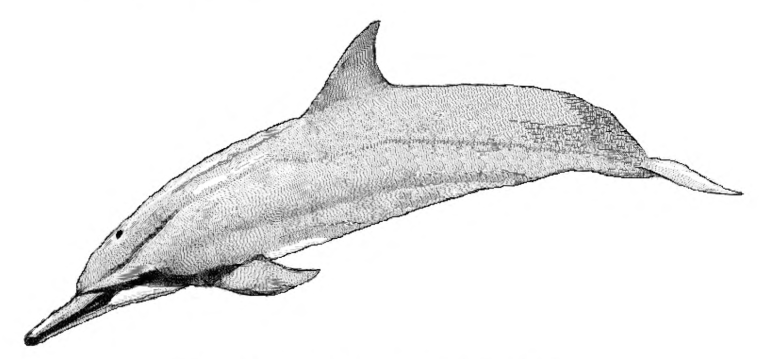

**Figure 5.7:** Stenella longirostris, spinner dolphin

PPn *taf(o,u)raqa ‘whale’ is well attested. Possible cognates occur in several non-Polynesian languages of central and southern Vanuatu, but these forms are probably borrowings from the Polynesian Outlier speech communities in these regions.

| **PPn** |  | *taf(o,u)raqa | ‘whale’ (pollex) |
| --- | --- | --- | --- |
| Pn | Tongan | *tofuaʔa* | ‘whale’ |
| Pn | Niuean | *tafuā* | ‘whale’ |
| Pn | East Uvean | *tafolaʔa* | ‘whale’ |
| Pn | Pukapukan | *tawolā* | ‘whale’ |
| Pn | Rennellese | *tahogaʔa* | ‘whale’ |
| Pn | Samoan | *tafolā* | ‘whale’ |
| Pn | Tuvalu | *tafolā* | ‘whale’ |
| Pn | Kapingamarangi | *toholā* | ‘whale’ |
| Pn | Tikopia | *taforā* | ‘cetacean, including whale, porpoise, dolphin’ |
| Pn | West Futunan | *tafora* | ‘whale’ |
| Pn | Hawaiian | *koholā* | ‘whale’ |

cf. also:

| NCV | Namakir | *taviraʔ* | ‘whale’ |
| --- | --- | --- | --- |
| NCV | South Efate | *tafra* | ‘whale’ |
| SV | Sye | *tovura* | ‘whale’ |
| SV | Kwamera | *təfra* | ‘whale’ |
| Fij | Wayan | *tavuto* | ‘generic for all large whales’ |
| Fij | Bauan | *tavuto* | ‘sperm whale, whose teeth furnish the tabua’ |

#### 4.1.2. Dolphins (Delphinidae)

Several species of dolphins, including Tursiops truncatus, the bottlenose dolphin, Stenella longirostris, the spinner dolphin and Grampus griseus, Risso’s dolphin, are found in Oceania (Dawbin 1972: 270-276). Wordlists and dictionaries of Oceanic languages give only generic terms for ‘dolphin’. The synonym ‘porpoise’ is commonly used in glosses.

POc *ku[r,R]iap, with final *-ap, is indicated by reflexes in North New Guinea, Papuan Tip and Meso-Melanesian languages and by *kulef* ‘dolphin’ in an external witness, Sawei, an Eastern Malayo-Polynesian language of South Halmahera. Southeast Solomonic and Vanuatu reflexes point to PEOc *giRio(p). Admiralties and SES languages reflect medial *-r-, while reflexes from NCV indicate *-R-. Other reflexes are compatible with either.

| **PEMP** |  | *kuriap | ‘dolphin’ |
| --- | --- | --- | --- |
| **POc** |  | *ku(r,R)iap | ‘dolphin’ |
| Adm | Nyindrou | *wiri* | ‘dolphin’ |
| Adm | Lou | *wiri* | ‘dolphin’ |
| Adm | Lenkau | *uhi* | ‘dolphin’ |
| Adm | Loniu | *wiʔɛ* | ‘dolphin’ |
| NNG | Mangap | *kuri* | ‘dolphin’ |
| NNG | Lukep | *kuri* | ‘dolphin’ |
| NNG | Mengen | *kule* | ‘dugong’ |
| NNG | Uvol | *ulia* | ‘dugong’ |
| NNG | Numbami | *kuliawa* | ‘dolphin’ |
| NNG | Mengen | *kulia* | ‘dolphin’ |
| PT | Dobu | *kuli-kuliya* | ‘dolphin’ |
| PT | Tawala | *uli-uliyawa* | ‘dolphin’ |
| PT | Kilivila | *kʷalivia* | ‘dolphin’ |
| MM | Tolai | *kuriap* | ‘dolphin’ |
| MM | Ramoaaina | *kuriap* | ‘dolphin’ |
| MM | Siar | *ku-kuriap* | ‘dolphin’ |
| SES | Bugotu | *kirio* | ‘dolphin’ |
| SES | Sa’a | *ʔirio* | ‘dolphin’ |
| SES | Kwaio | *kilio* | ‘dolphin’ |
| SES | Lau | *kirio* | ‘dolphin’ |
| SES | Bauro | *kirio* | ‘dolphin’ |
| SES | Arosi | *girio* | ‘dolphin’ |
| **PNCV** |  | *guRio | ‘dolphin (generic)’[^7] |
| NCV | Hiw | *kʷʟi* | ‘dolphin’ |
| NCV | Loh | *kʷuriə* | ‘dolphin’ |
| NCV | Mota | *kio* | ‘whale’ |
| NCV | Ambae | *kio* | ‘dolphin’ |
| NCV | Raga | *gio* | ‘dolphin’ |
| NCV | Lewo | *(le)kio-kio* | ‘dolphin’ |
| NCV | Shark Bay | *kuo* | ‘dolphin’ |
| NCV | Namakir | *qio-qi* | ‘dolphin’ |
| NCV | Nguna | *giio* | ‘dolphin’ |
| **PMic** |  | *kua | ‘dolphin’[^8] |
| Mic | Kiribati | *te-kua* | ‘dolphin, whale’ |
| Mic | Marshallese | *ke* | ‘dolphin’ |
| Mic | Woleaian | *xüw* | ‘dolphin’ |
| Mic | Puluwatese | *kūw* | ‘porpoises, believed to be whales when fully grown’ |

cf. also:

| SV | Sye | *(so)furwav(oh)* | ‘dolphin’[^9] |
| --- | --- | --- | --- |
| SV | Ura | *(so)furwav(os)* | ‘dolphin’ |
| Fij | Bauan | *giō* | ‘shark (generic)’ |
| Fij | Kadavu | *giō* | ‘shark (generic)’ |

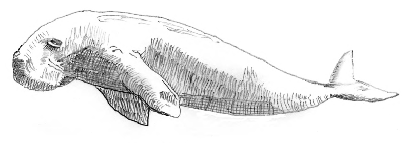

**Figure 5.8:** *Dugong dugon*, dugong

### 4.2. Dugong (*Dugong dugon*)

Dugongs are large aquatic mammals, with paddle-like forelimbs, no hindlimbs and a fluked, dolphin-like tail. They graze on beds of seagrass and are found in shallow coastal waters throughout the Indo-Malaysian archipelago, New Guinea and nearby islands including the Admiralties and Bismarcks, and in the Solomons, Vanuatu and New Caledonia, but not in Fiji or places further east (Chambers et al. 1989:1). Dugongs are prized by Pacific Islanders for their flesh, oil and small ivory tusks. Spears and nets are the main methods of capture. In the Trobriands and Manus very strong nets made from pandanus leaves are used while in the Siassi islands nets are made from the bark of a tree (Pyne 1972:276).

There is a well attested PMP etymon, *duyuŋ ‘dugong’. While most Oceanic reflexes point to *rui, evidence that POc continued PMP *duyuŋ as *ruyuŋ survives in the Tiang (New Ireland) reflex, which preserves the final velar nasal, and in Marovo (New Georgia), which retains a nasal, though this is *m* for expected *-ŋ.

| **PMP** |  | *duyuŋ | ‘dugong’ (Blust 2002) |
| --- | --- | --- | --- |
| **POc** |  | *ruyuŋ | ‘dugong’ |
| Adm | Pak | *hū* | ‘dugong’ |
| Adm | Bipi | *xū* | ‘dugong’ |
| Adm | Nauna | *tuy* | ‘dugong’ |
| Adm | Drehet | *kxu* | ‘dugong’ |
| NNG | Kove | *lui* | ‘dugong’ |
| NNG | Bariai | *rui* | ‘dugong’ |
| NNG | Gitua | *rui* | ‘dugong’ |
| NNG | Bing | *rui* | ‘dugong’ |
| NNG | Malasanga | *rui-rui* | ‘dugong’ |
| NNG | Sio | *(gu)rui* | ‘dugong’ |
| NNG | Lamogai | *dū* | ‘dugong’ |
| NNG | Takia | *rui* | ‘dugong’ |
| PT | Iduna | *lui* | ‘dugong’ |
| PT | Motu | *rui* | ‘dugong’ |
| PT | Magori | *rui* | ‘dugong’ |
| MM | Bulu | *rui* | ‘dugong’ |
| MM | Tiang | *iuŋ* | ‘dugong’ |
| MM | Marovo | *rumu* | (*-m-* for †*-ŋ-*) |

cf. also:

| NNG | Kaiep | *kuoi* | ‘dugong’ |
| --- | --- | --- | --- |
| NNG | Kairiru | *qui* | ‘dugong’ |
| MM | Babatana | *jui* | ‘dugong’ |

## 5. Reptiles

### 5.1. Marine turtles (Chelonidae)

At least four large species of marine turtles are common to the Oceanic region: the hawksbill (Eretmochelys imbricatd), with its beak-like mouth, the green turtle (*Chelonia mydas*), with brown or black carapace, the loggerhead (*Caretta caretta*), with its very large head, and the leatherback (*Dermochelys coriacea*), distinguished from other turtles by its lack of a bony shell, its carapace being covered by thick leathery skin. The much smaller olive fidley (Lep- idochelys olivacea) spends almost all of its time in the open ocean and is less familiar to Pacific Islanders. Turtles are prized by Oceanic communities for their flesh and fat and (in the case of the hawksbill) for their shells.

As well as having a generic for ‘turtle’, a number of languages have distinct names for all four species and some distinguish male and female turtles, as the following examples show.

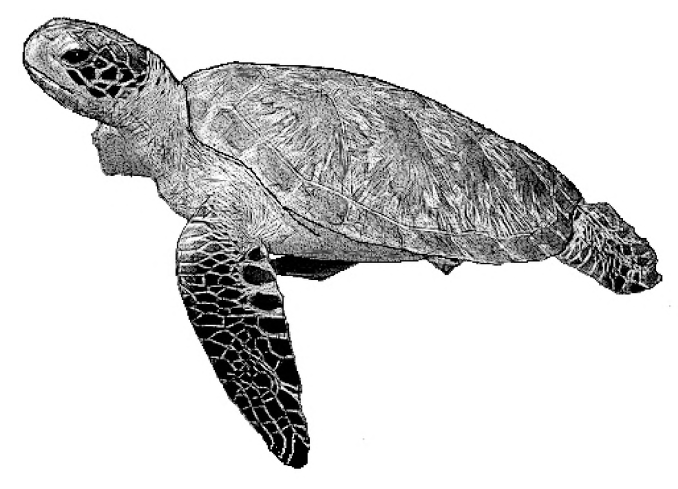

**Figure 5.9:** *Chelonia mydas*, green turtle

| NNG | Lukep | *pon* | ‘turtle’ |
| --- | --- | --- | --- |
| NNG | Lukep | *olol* | ‘hawksbill turtle’ |
| NNG | Lukep | *padodo* | ‘green turtle’ |
| NNG | Lukep | *kawadui* | ‘leatherback turtle’ |
| MM | Kia | *tege* | ‘turtle generic’ |
| MM | Kia | *tege ŋapo* | ‘hawksbill turtle’ |
| MM | Kia | *tege mogaha* | ‘green turtle’ |
| MM | Kia | *tege babaru* | ‘leatherback turtle’ |
| MM | Kia | *tege kakapodoko* | ‘loggerhead turtle’ |
| MM | Marovo | *vonu* | ‘turtle (generic)’ |
| MM | Marovo | *vonu pede* | ‘hawksbill turtle’ |
| MM | Marovo | *vonu ihana* | ‘green turtle’ |
| MM | Marovo | *kariatolu* | ‘leatherback turtle’ |
| MM | Marovo | *kakapodoko* | ‘loggerhead turtle’ |
| SES | Sa’a | *honu* | ‘turtle (generic)’ |
| SES | Sa’a | *honu hapa* | ‘hawksbill turtle’ (*hapa* ‘turtleshell’) |
| SES | Sa’a | *honu iʔe* | ‘green turtle’ (*iʔe* ‘fish’) |
| SES | Sa’a | *kule oŋo* | ‘leatherback turtle’ (*kule* ‘shore’, *oŋo* ‘mangrove’) |
| SES | Arosi | *honu* | ‘turtle (generic)’ |
| SES | Arosi | *honu hapa* | ‘hawksbill turtle’ |
| SES | Arosi | *honu hau* | ‘soft-shelled turtle’ (?) |
| SES | Arosi | *honu marabona* | ‘large sp. of turtle’ |
| SES | Arosi | *honu orobiu* | ‘leatherback turtle’ |
| SES | Arosi | *honu ʔeʔero* | ‘female turtle’ |
| SES | Arosi | *honu maraw* | ‘male turtle’ |
| Mic | Chuukese | *wīn* | ‘generic for sea turtles’ |
| Mic | Chuukese | *māw* | ‘hawksbill turtle’ |
| Mic | Chuukese | *winic̣c̣en* | ‘hawksbill turtle’ |
| Mic | Chuukese | *winimʷen* | ‘green turtle’ |
| Mic | Chuukese | *woŋ* | ‘leatherback turtle’ |
| Fij | Wayan | *ika-bula* | ‘turtle generic’ |
| Fij | Wayan | *taku* | ‘hawksbill turtle’ |
| Fij | Wayan | *ika-dū* | ‘green turtle’ |
| Fij | Wayan | *tosiviwalu* | ‘leatherback turtle’ |
| Fij | Wayan | *tū-vonu* | ‘loggerhead turtle’ |
| Fij | Wayan | *bala* | ‘male turtle’ |
| Pn | Tikopia | *fonu* | ‘turtle (generic)’ |
| Pn | Tikopia | *fonu koroa* | ‘hawksbill turtle’ (*koroa* ‘goods, treasure’) |
| Pn | Tikopia | *fonu tea* | ‘green turtle’ (*tea* ‘white, light-coloured’) |

Three terms for turtle taxa are attributable to POc. POc *poñu, continuing a PAn etymon, was clearly the generic term, and is very well supported.

| **PAn** |  | *peñu | ‘turtle’ (ACD) |
| --- | --- | --- | --- |
| **POc** |  | *poñu | ‘turtle (generic)’ |
| Adm | Mussau | *onu* | ‘turtle (generic)’ |
| Adm | Wuvulu | *fonu* | ‘large hard-shelled sea turtle’ |
| Adm | Aua | *fonu* | ‘large hard-shelled sea turtle’ |
| Adm | Lou | *puon* | ‘sea turtle’ |
| Adm | Loniu | *poñ* | ‘sea turtle’ |
| NNG | Manam | *poŋ* | ‘turtle’ |
| NNG | Lukep | *pon* | ‘turtle, Dermochelidae’ |
| NNG | Gedaged | *fon* | ‘leatherback turtle’ |
| NNG | Kove | *ponu* | ‘turtle’ |
| PT | Tubetube | *wonu* | ‘turtle’ |
| PT | Kilivila | *wonu* | ‘turtle’ |
| MM | Tigak | *un* | ‘turtle’ |
| MM | East Kara | *fun* | ‘turtle’ |
| MM | Nalik | *fun* | ‘turtle’ |
| MM | Tabar | *vo* | ‘turtle’ |
| MM | Lihir | *on* | ‘turtle’ |
| MM | Sursurunga | *hun* | ‘turtle’ |
| MM | Tangga | *fon* | ‘turtle’ |
| MM | Patpatar | *hun* | ‘turtle’ |
| MM | Nehan | *won* | ‘turtle’ |
| MM | Marovo | *vonu* | ‘turtle (generic)’ |
| MM | Taiof | *fon* | ‘turtle’ |
| MM | Banoni | *ɣom* | ‘turtle’ |
| MM | Babatana | *vunu* | ‘turtle’ |
| MM | Lungga | *voñu* | ‘turtle’ |
| SES | Bugotu | *voñu* | ‘turtle’ |
| SES | Gela | *vonu* | ‘turtle (generic) for hawksbill and green turtle’ (Foale) |
| SES | Lau | *fonu* | ‘turtle’ |
| SES | Kwaio | *fonu* | ‘turtle’ |
| SES | Sa’a | *honu* | ‘turtle’ |
| SES | Arosi | *honu* | ‘turtle’ |
| NCal | Jawe | *pʷen* | ‘turtle’ |
| NCal | Nemi | *pʷen* | ‘turtle’ |
| NCal | Xârâcùù | *pʷê* | ‘turtle’ |
| Mic | Kiribati | *on* | ‘turtle’ |
| Mic | Chuukese | *woŋ* | ‘leatherback turtle’ |
| Mic | Carolinian | *wōŋ* | ‘turtle’ |
| Mic | Woleaian | *woŋ* | ‘turtle’ |
| Mic | Ulithian | *wōl* | ‘turtle’ |
| Fij | Bauan | *vonu* | ‘turtle (generic)’ |
| Fij | Wayan | *(tu)vonu* | ‘loggerhead turtle’ |
| Pn | Tongan | *fonu* | ‘turtle (generic)’ |
| Pn | Niuean | *fonu* | ‘turtle’ |
| Pn | Rennellese | *honu* | ‘green turtle’ |
| Pn | East Futunan | *fonu* | ‘turtle’ |
| Pn | Tikopia | *fonu* | ‘turtle (generic)’ |
| Pn | Hawaiian | *honu* | ‘turtle’ |

The shell of the hawksbill turtle is prized, being used to make ornaments like earrings and bracelets as well as bonito hook tips and cutting tools. In Tonga and E. Futuna this turtle is called *fonu koloa*, in Tikopia *fonu koroa*, the term for ‘property, treasure’ being used to identify the turtle with valuable shell.

A term for the hawksbill turtle, *keRaŋ is well supported. In Oceanic languages, the beaked profile of the hawksbill turtle is identified with that of a parrot rather than a hawk. In Lou (Admiralties), the same term refers to both the turtle and a red parrot. In Maori the term survives only for the parrot. (For discussion of the atypical /e/ vowel, see Blust 1983-84:8-10). All the Admiralties terms have problematic reflexes of *R and all show vowel metathesis.

| **PCEMP** |  | *keRaŋ | ‘hawksbill turtle’ (Blust 2002) |
| --- | --- | --- | --- |
| **POc** |  | *keRaŋ | ‘hawksbill turtle, *Eretmochelys imbricata*’ |
| Adm | Lou | *kareŋ* | ‘hawksbill turtle; red parrot’ |
| Adm | Lenkau | *kareŋ* | ‘hawksbill turtle’ |
| Adm | Pak | *kareŋ* | ‘hawksbill turtle’ |
| Adm | Titan | *karéŋ* | ‘parrot turtle’ |
| Adm | Andra | *kareŋ* | ‘hawksbill turtle’ |
| PT | Motu | *era* | ‘turtle, shell turtle’ |
| Mic | Kiribati | *(tabʷa)kea* | ‘parrotbill turtle, brilliant shell’ |
| Mic | Ponapean | *(sapʷa)ke* | ‘hawksbill turtle’ |
| **PPn** |  | *kea | ‘hawksbill turtle’ |
| Pn | Pukapukan | *kea* | ‘k.o. turtle’ |
| Pn | Nanumea | *kea* | ‘a small turtle’ |
| Pn | Rennellese | *kea* | ‘qualifier for small turtles’ |
| Pn | Māori | *kea* | ‘parrot sp.’ |
| Pn | Hawaiian | *ʔea* | ‘hawksbill turtle; also term for its shell’ |

The green turtle is the most abundant and widespread turtle of tropical Oceania and the one most valued for food. It may weigh up to 200 kg, with carapace length around 150 cm. A POc term is reconstructable but reflexes have been found only in a few North New Guinea and Micronesian languages.

| **POc** |  | *manak(V) | ‘green turtle, *Chelonia mydas*’ |
| --- | --- | --- | --- |
| NNG | Takia | *manak* | ‘green turtle’ |
| NNG | Gedaged | *manak* | ‘green turtle’ |
| Mic | Carolinian | *mʷēl* | ‘turtle with thin shell, good for eating’ |
| Mic | Chuukese | *(wini)mʷən* | ‘green turtle, eaten’ |
| Mic | Puluwatese | *mʷol* | ‘green turtle, commonly caught and distributed to entire island’ |

The leatherback turtle, *Dermochelys coriacea*, is the largest turtle in the world with an average carapace length of two metres and average weight of around 360 kg. It nests widely along the north coast of New Guinea, Manus, New Britain and Bougainville, but always in very low densities. It is generally not favoured for eating because of its very oily and smelly meat (Mueller 1985:195). No widespread cognate set has been found.

### 5.2. Crocodiles (Crocodylidae)

The archaeologist Simon Best has published a comprehensive review of the distribution of crocodiles in the Pacific (Best 1988). Two species occur in Melanesia: *Crocodylus porosus*, the estuarine or saltwater crocodile and *Crocodylus novaeguineae*. The latter is found in freshwater swamps and lakes in lowland New Guinea. The normal (breeding) range of *Crocodylus porosus* extends from south-west India to the Solomons, and from the Tropic of Capricorn in Australia to the Philippines. The easternmost limit for breeding populations is the Santa Cruz group. Individual animals are capable of very long journeys, over 1000 km, and have been reliably recorded in northern Vanuatu, Fiji and Kiribati, but these occasional occurrences do not represent an extension of their breeding range.

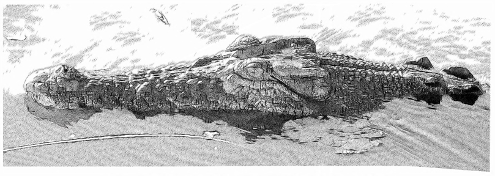

**Figure 5.10:** *Crocodylus porosus*, saltwater crocodile

POc *puqaya ‘crocodile’ continues PMP *buqaya and, probably, PAn *buqaya.[^10]: Reflexes of *puqaya are found widely in languages of the Bismarck Archipelago, New Guinea and the main Solomons group, i.e. where crocodiles are common, and are also present in a few languages of Vanuatu. No reflexes have been recorded in Micronesian or Central Pacific languages.

| **PAn** |  | *buqaya | ‘crocodile’ (ACD) |
| --- | --- | --- | --- |
| **POc** |  | *puqaya | ‘crocodile’ |
| Adm | Mussau | *ua* | ‘crocodile’ |
| Adm | Nyindrou | *buwa* | ‘crocodile’ |
| Adm | Lou | *pua* | ‘crocodile’ |
| Adm | Aua | *fuara* | ‘crocodile’ |
| NNG | Kilenge | *na-pua* | ‘crocodile’ |
| NNG | Malasanga | *pua* | ‘crocodile’ |
| NNG | Roinji | *puɣaia* | ‘crocodile’ |
| NNG | Adzera | *fugai* | ‘crocodile’ |
| PT | Arifama | *uaya* | ‘crocodile’ |
| PT | Dobu | *uaya* | ‘crocodile’ |
| PT | Hula | *vuɣa* | ‘crocodile’ |
| PT | Motu | *huala* | ‘crocodile’ |
| MM | Vitu | *vuɣa* | ‘crocodile’ |
| MM | Lavongai | *uaia* | ‘crocodile’ |
| MM | Patpatar | *huaia* | ‘crocodile’ |
| MM | Petats | *hua* | ‘crocodile’ |
| MM | Marovo | *vua* | ‘crocodile’ |
| SES | Gela | *vua* | ‘crocodile’ |
| SES | Lau | *fuasa* | ‘crocodile’ |
| SES | ’Are’are | *huara* | ‘crocodile’ |
| SES | Sa’a | *huasa* | ‘crocodile’ |
| NCV | Mota | *via* |  |
| NCV | Mwotlap | *ne-ve* | ‘crocodile’ |

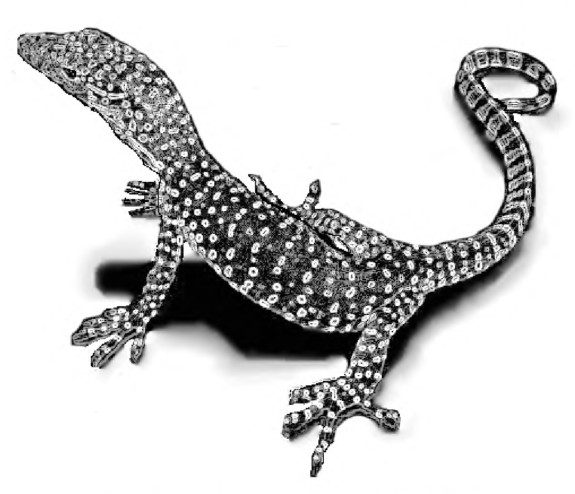

**Figure 5.11:** *Varanus indicus*, water monitor

### 5.3. Lizards

#### 5.3.1. Introduction

Lizards are discussed here under the following headings: monitors (§5.3.2), iguanas (§5.3.3), geckos (§5.3.4), skinks (§5.3.5) and indeterminate (§5.3.6), but there is frequent transfer of name within cognate sets from one family to another. Monitor lizards and iguanas belong to different families, although these names are used interchangeably in some wordlists. The Australian goanna belongs with the monitor lizards of Indonesia, New Guinea and the western Pacific. The iguana is of South American origin, and is found in the Pacific today only in the Galapagos Islands, Fiji, Tonga, Wallis and Futuna. In many sources the gloss ‘iguana’ is incorrectly applied to monitor lizards.

#### 5.3.2. Monitors (Varanidae)

Nearly a score of different species of monitors are to be found in the Indo-Pacific region. The best known, because of its great size, is the komodo monitor, a species confined to the Lesser Sundas. The most widespread species in Oceania is *Varanus indicus*, a water monitor, valued as an important food source. Its range extends from Sulawesi through to the Aru and Kei Islands, the New Guinea land mass including the Schouten Islands, the D’Entrecasteaux and Trobriand Islands, New Britain, New Ireland, the Admiralties, the Solomons and northwards to the Carolines, Marianas and Marshalls (Loveridge 1946:60-64, de Rooij 1970:149). Water monitors can grow to over two metres in length, with the tail about one and a half times as long as the head and body. They are excellent swimmers, and have been seen swimming far out to sea.

De Rooij lists five other Varanus species in New Guinea (*V. salvadorii*, *V. kalabeck*, *V. gouldi*, *V. prasinus*, *V. kordensis*), but none are found outside the main island except for the last-named which is found also on Aru. The fact that Arosi has two terms for monitor lizard (incorrectly glossed ‘iguana’ by Fox), *haha*, ‘the larger’, *ʔaraʔu*, ‘the smaller’, may indicate sub-species or a distinction based on sex or age. The skin of the larger monitors is used in New Guinea to cover the end of hourglass drums. The POc term *ka(r,l)(i,u)pa(s) probably referred to large monitor lizards.

| **POc** |  | *ka(r,l)(i,u)pa(s) | ‘large monitor lizard, *Varanus indicus* and possibly other species’ |
| --- | --- | --- | --- |
| PT | Muyuw | *kalevas* | ‘tree goanna, big lizard’ |
| PT | Motu | *ariha* | ‘large lizard, iguana’ (= monitor; *r* for *l unexpected) |
| SES | Tolo | *kolahe* | ‘k.o. lizard’ (vowel metathesis) |
| SES | Lau | *kurafe* | ‘k.o. large lizard with smooth shining body’ (vowel metathesis) |
| **PMic** |  | *kalufa | ‘monitor lizard’ |
| Mic | Chuukese | *konuf* | ‘*Varanus indicus*, monitor lizard’ |
| Mic | Mortlockese | *kaluf* | ‘lizard’ |
| Mic | Puluwatese | *kólūf* | ‘giant lizard’ |
| Mic | Satawalese | *kaluf* | ‘lizard’ |
| Mic | Carolinian | *xalūf* | ‘black and green forest lizard: gecko’ |
| Mic | Woleaian | *xarüfa* | ‘k.o. big lizard’ |

cf. also:

| SES | To’aba’ita | *gʷalu(aʔa)* | ‘green-blooded skink, *Prasinohaema virens*’ |
| --- | --- | --- | --- |

There is a second, more weakly supported POc reconstruction, *wak(i,e) ‘k.o. lizard, possibly monitor lizard’. It may be a contraction of PMP *bayawak ‘monitor lizard’ (Blust 2002).

| **POc** |  | *wak(i,e) | ‘k.o. lizard, possibly a monitor’ |
| --- | --- | --- | --- |
| Adm | Lou | *wak* | ‘monitor lizard, *Varanus* sp.’ |
| PT | Minaveha | *wake(neta)* | ‘lizard, rough-skinned’ |
| PT | Dobu | *waki-waki* | ‘small gecko’ |
| PT | Dobu | *waki(balu)* | ‘large gecko’ |
| SES | ’Are’are | *weʔe* | ‘k.o. big lizard that eats the inside of the *nari* nut’ |

Reflexes of the next reconstruction, POc *(k,g)uma, form a compound in many PT languages with reflexes of POc *ka(r,R)ak ‘creep, crawl’.

| **POc** |  | *(k,g)uma | ‘monitor lizard’ |
| --- | --- | --- | --- |
| **PPT** |  | *(k,g)uma-kara | ‘monitor lizard’ |
| PT | Ubir | *umar* | ‘lizard, general term’ |
| PT | Gapapaiwa | *kuma-kara* | ‘lizard (monitor type?); the skin of this lizard is used for drum heads’ |
| PT | Saliba | *kuma-kala* | ‘k.o. lizard’ |
| PT | Minaveha | *kuma-kana* | ‘lizard which lives near ocean’ |
| PT | Minaveha | *um-ana* | ‘larger lizards, speckled or striped, with smooth skin’ |
| PT | Dobu | *goma-ʔara* | ‘monitor lizard’ |
| PT | Wedau | *umara* | ‘k.o. lizard’ |
| PT | Tawala | *umʷala* | ‘iguana, large black lizard’ |
| PT | Iduna | *uma-ʔala* | ‘goanna; goanna skin of drum’ |
| PT | Galea | *guma-ʔala* | ‘monitor lizard’ |
| PT | Molima | *goma-ʔala* | ‘monitor lizard’ |
| MM | Tolai | *gom* | ‘k.o. small lizard’ |
| Mic | Woleaian | *xumʷa(ṣere)* | ‘k.o. small lizard’ (*ṣere* ‘gruel’) |

| **PWOc** |  | *paRia | ‘k.o. big lizard’ |
| --- | --- | --- | --- |
| NNG | Manam | *paria* | ‘k.o. big lizard’ |
| NNG | Bariai | *paria* | ‘lizard (generic)’ |
| NNG | Kove | *pahia* | ‘monitor lizard’ |
| NNG | Sengseng | *a-pahiya* | ‘monitor lizard’ |
| NNG | Lukep | *pari* | ‘large ground lizard’ |
| NNG | Gedaged | *paɬiu* | ‘k.o. lizard, edible, skin used as drum head. Gets to be seven feet long’ |
| PT | Motu | *aria* | ‘lizard (generic); monitor lizard’ (for †*haria*) |
| MM | Roviana | *vari(lazu)* | ‘k.o. lizard’ |

cf. also:

| MM | Nakanai | *vareki* | ‘monitor lizard, skin used for drum-head’ |
| --- | --- | --- | --- |

There is a well supported Proto Admiralties reconstruction for monitor lizard.

| **PAdm** |  | *watiRi | ‘monitor lizard, *Varanus* spp.’ |
| --- | --- | --- | --- |
| Adm | Wuvulu | *waʔi* | ‘monitor lizard, *Varanus* spp.’ |
| Adm | Seimat | *wat* | ‘monitor lizard, *Varanus* spp.’ |
| Adm | Penchal | *wati* | ‘monitor lizard, *Varanus* spp.’ |
| Adm | Nali | *wariy* | ‘monitor lizard, *Varanus* spp.’ |
| Adm | Lele | *watiy* | ‘monitor lizard, *Varanus* spp.’ |
| Adm | Titan | *wati* | ‘monitor lizard, *Varanus* spp.’ |
| Adm | Loniu | *wati* | ‘lizard’ |
| Adm | Bipi | *wati* | ‘monitor lizard, *Varanus* spp.’ |

#### 5.3.3. Iguanas (Iguanidae)

True iguanas, in contrast to monitor lizards, would not have been known to speakers of POc. Iguanas (*Brachylophus* spp.) are present in the Oceanic region only in Fiji, Tonga, Wallis and Futuna. They are of South American origin and probably arrived in the central Pacific on floating vegetation. They are diurnal and strongly arboreal in behaviour. A Proto Central Pacific name for ‘iguana’, *vokai, is reconstructable from cognates in Fijian and Polynesian languages. No non-CP cognates have been recorded. In Rennellese the reflex of *vokai is applied to monitor lizards. The Tongan term identified in the dictionary as ‘chameleon’ probably refers to a lizard with chameleon-like ability to change colour; true chameleons are natives of Africa. Paddy Ryan reports that *Brachylophus vitiensis*, the crested iguana, has the ability to change colour when frightened or angry and will turn a very dark green, almost black, within five minutes (Ryan 1988:106).

| **PCP** |  | *vokai | ‘k.o. lizard’ |
| --- | --- | --- | --- |
| Fij | Bauan | *vokai* | ‘banded iguana (*Brachylophus fascialus*) and crested iguana (*Brachylophus vitiensis*)’ |
| Fij | Wayan | *vokai* | ‘crested iguana’ |
| Pn | Tongan | *fokai* | ‘chameleon’ |
| Pn | Rennellese | *hokai* | ‘general name for monitor lizards, *Varanus indicus*’ |

cf. also:

| NCV | Tamambo | *vohare* | ‘k.o. lizard’ |
| --- | --- | --- | --- |

#### 5.3.4. Geckos (Gekkonidae)

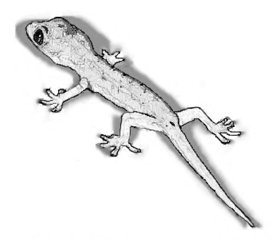

**Figure 5.12:** *Hemidactylus frenatus*, common house gecko

Geckos are widely distributed across mainland Southeast Asia, Indonesia and the tropical Pacific. They are one of the few reptiles with voices; they make small chirruping noises. They are mostly nocturnal, and many species frequent buildings, although others are forest dwellers. Most are less than 15cm long, and, in common with skinks, have the ability to discard their tails when threatened. They are generally welcomed by households, both for their efforts in keeping down moths, mosquitos, cockroaches and other household pests, and because they are widely regarded as good omens (Loveridge 1946:73).

A number of Western Malayo-Polynesian terms for gecko are onomatopoeic, typically reflexes of PMP *tektek. Although there are numerous gecko species throughout the Oceanic region, only one term which might be considered a reflex of PMP *tektek has been noted.

| **PMP** |  | *tektek | ‘gecko, house lizard (onom.)’ (doublet *cekcek) (ACD) |
| --- | --- | --- | --- |
| **POc** |  | *tok | ‘gecko’ |
| NNG | Hote | *(kamu)tok* | ‘small gecko, found on the wall’ |

We have reconstructed POc *bili ‘k.o. lizard’, which may be an irregular reflex of a PAn term, *bulilik ‘lizard sp.’ (Blust 2002), but on present evidence the connection is uncertain. Its reflexes in Polynesian languages carry two meanings, ‘gecko’ (or sometimes ‘lizard (generic)’) and ‘adhere to’, pointing to a lizard name that reflects its character.

Some of the Polynesian reflexes may be compounded with the generic term for lizard, PPn *moko, from POc *mo(g,k)o ‘k.o. snake’ (see §5.4.1).

| **POc** |  | *bili | ‘k.o. lizard’ |
| --- | --- | --- | --- |
| MM | Tolai | *bil-bil* | ‘k.o. lizard’ |
| **PPn** |  | *pili | ‘gecko; adhere to’ (pollex) |
| Pn | Tongan | *pili* | ‘k.o. bluish lizard’ |
| Pn | East Futunan | *pili(moko)* | ‘gecko’ |
| Pn | Pukapukan | *(ŋō)pili* | ‘gecko’ |
| Pn | Samoan | *pili* | ‘lizard’ |
| Pn | Takuu | *(moko)pili* | ‘small house lizard’ |

cf. also:

| Pn | Tikopia | *(moko)pili* | ‘gecko’ (for †*piri*) |
| --- | --- | --- | --- |

#### 5.3.5. Skinks (Scincidae)

Most skinks are slim lizards capable of moving at high speed, although the family includes the more heavily built blue-tongue lizards. Skinks usually emerge during the day to feed and bask in the sun. The New Guinea blue-tongue skink, *Tiliqua gigas*, is widely distributed across eastern Indonesia, the New Guinea mainland, the Admiralty islands and Bismarck Archipelago (http://www.anapsid.org/bluetong.html). Various Emoia species are widely distributed through New Guinea and the Pacific. Contemporary languages often distinguish a number of skink taxa but no POc reconstructions that refer specifically to skinks are supported. However, John Lynch (pers. comm.) has proposed a reconstruction for Proto Southern Oceanic, based on cognates in NCV and New Caledonia, and there is evidence for a second term attributable to Proto Eastern Oceanic.

| **PSOc** |  | *gala | ‘green lizard, *Emoia* sp.’ (John Lynch, pers. comm.) |
| --- | --- | --- | --- |
| NCV | Mota | *kala* | ‘small blue lizard’ |
| NCV | Dorig | *kal* | ‘green lizard’ |
| NCV | Raga | *ɣala* | ‘lizard, probably green skink, *Emoia sanfordi*’ |
| NCV | Tamambo | *kala* | ‘small green lizard, about 30 cm long, generally reviled.’ |
| NCV | Ambae | *kala* | ‘shiny green lizard w. long tail, grows to about 20cm, lives on coconut palms’ |
| NCV | Lonwolwol | *gal* | ‘green lizard’ |
| NCV | Paamese (South) | *a-kal* | ‘green lizard, *Emoia sanfordi*’ |
| NCal | Nemi | *gēna* | ‘lizard (generic)’ |

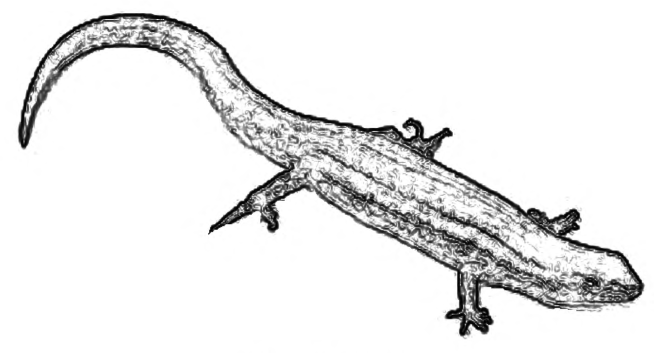

**Figure 5.13:** Skink

The presence of *kali in the following reconstruction raises the question as to whether this is an echo of the old *qali-*/*kali-* prefix that in pre-Oceanic times evidently meant something like ‘Warning. Take care!’ (See ch. 7 for detailed discussion.) Although the evidence is that the morpheme was no longer productive in Oceanic languages, an association of danger with a kind of iridescent lizard persists, at least in Tamambo (NCV) and Tikopia (Pn). Jauncey (pers. comm.) notes that in Tamambo they are generally reviled, people shuddering at the sight of them. Firth (1967:233) observes that Tikopia *atua*, which applies primarily to a supernatural entity, is extended as a category name to any natural species which should not be eaten. Among the latter he includes iridescent lizards.

| **PEOc** |  | *kalis(i,u) | ‘k.o. skink’ |
| --- | --- | --- | --- |
| SES | Owa | *ga-garisu* | ‘a brown skink’ |
| **PPn** |  | *kalisi | ‘skink, k.o. lizard’ (pollex) |
| Pn | Tongan | *kalihe-lihe* | ‘k.o. lizard’ |
| Pn | Rennellese | *kagisi* | ‘skink (*Emoia cyanura*)’ |
| Pn | Nanumea | *kalihi* | ‘skink’ |
| Pn | Kapingamarangi | *galiha* | ‘skink’ |
| Pn | Tikopia | *kali-lisi* | ‘green lizard, small, iridescent’ |

#### 5.3.6. Indeterminate kinds of lizards

There is a weakly supported reconstruction based on an imperfect agreement between Southeast Solomonic languages and Tolai.

| **POc** |  | *kuk(o,u) | ‘k.o. lizard’ |
| --- | --- | --- | --- |
| MM | Tolai | *kuku* | ‘lizard (generic) name’ (*kuku alira* ‘small lizard w bronze tail’; also ‘green’) |
| SES | ’Are’are | *ʔuʔo* | ‘small lizard, green and gold’ |
| SES | Sa’a | *uʔo* | ‘house lizard, green and gold; first element in several lizard names’ |

A second weakly supported reconstruction rests on putative cognates in Mussau, Kokota and N Tanna.

| **POc** |  | *kapoRu | ‘k.o. lizard’ |
| --- | --- | --- | --- |
| Adm | Mussau | *kapou* | ‘monitor lizard, *Varanus* sp.’ |
| MM | Kokota | *kopro* | ‘gecko’ |
| SV | North Tanna | *kapʷer* | ‘lizard’ (*-r* for †∅) (Tryon 1995) |

cf. also:

| CB | Serui-Laut | *kafei* | ‘house lizard’ (Smits 1992:239) |
| --- | --- | --- | --- |
| PT | Molima | *kekepa* | ‘green tree skink’ |
| MM | Nakanai | *kavega* | ‘lizard’ |
| MM | Tolai | *keveu* | ‘k.o. iguana’ (monitor) |

### 5.4. Snakes (sub-order Serpentes)

#### 5.4.1. Land snakes

Around 100 species of land snakes occur in New Guinea, the Bismarck Archipelago and the Solomon Islands. They include pythons and boas (family Boidae), both of which constrict their prey, and a range of tree snakes and ground-dwelling snakes, some of which are highly venomous. The best known include the Papuan taipan, *Oxyuranus scutellatus*, the Papuan black snake, *Pseudechis papuanus*, and the death adder, *Acanthophis antarcticus*.

Only two species of snake have been reported for Vanuatu: the Flowerpot Snake, Typhlops braminus of Efate and the Pacific Boa, Candoia bibroni, also with restricted distribution (Medway and Marshall, quoted in Walsh et al. 2000:248). Fiji has two terrestrial snakes, the Pacific boa and the rare Ogmodon vitianiis, the latter found only in Fiji (Ryan 1988:111-114, Morrison 2003:90). In Polynesia land snakes are found only in Samoa, while the only land snake reported for Micronesia is the miniature blind snake found on Chuuk (Davis 1999:188). For PMP *nipay ‘snake’ only a single Oceanic reflex has been located.

| **PMP** |  | *nipay | ‘snake’ (ACD) |
| --- | --- | --- | --- |
| **POc** |  | *nipe | ‘snake’ |
| MM | Mono-Alu | *nihe* | ‘snake’ |

POc *mʷata is the most widely reflected generic for ‘snake’ in Oceanic languages. It has no known non-Oceanic cognates, raising the possibility that this term entered Proto Oceanic from a non-Austronesian source.

| **POc** |  | *mʷata | ‘snake (generic)’ (Ross 1988) |
| --- | --- | --- | --- |
| Adm | Wuvulu | *waʔa* | ‘snake (generic)’ |
| Adm | Aua | *waʔa* | ‘snake (generic)’ |
| Adm | Loniu | *mʷat* |  |
| Adm | Nauna | *mʷat* | ‘snake (generic)’ |
| Adm | Bipi | *mʷak* | ‘snake (generic)’ |
| SJ | Ormu | *mata-mata* | ‘snake (generic)’ |
| SJ | Sobei | *matu* | ‘snake (generic)’ |
| NNG | Yabem | *mɔaʔ* | ‘snake (generic)’ |
| NNG | Manam | *moata* | ‘snake (generic)’ |
| NNG | Gedaged | *mot* | ‘collective term for snakes and certain kinds of worms’ |
| NNG | Kove | *mota* | ‘snake (generic)’ |
| NNG | Malasanga | *mota* | ‘snake (generic)’ |
| NNG | South Watut | *mʷar* | ‘snake (generic)’ |
| PT | Are | *mota* | ‘snake (generic)’ |
| PT | Tawala | *mota* | ‘snake (generic)’ |
| PT | Molima | *mʷata* | ‘snake (generic)’ |
| PT | Tubetube | *mʷata* | ‘snake (generic)’ |
| PT | Sudest | *mʷata* | ‘snake (generic)’ |
| MM | Bola | *mata* | ‘snake (generic)’ |
| MM | Bali | *(gu)mata* | ‘snake (generic)’ |
| MM | Tigak | *mʷata* | ‘snake (generic)’ |
| SES | Bugotu | *umata* | ‘snake (generic)’ |
| SES | Gela | *umata* | ‘snake (generic)’ |
| SES | Longgu | *mʷa* | ‘snake (generic)’ |
| SES | Lau | *wa* | ‘snake (generic)’ |
| SES | Kwaio | *wā* | ‘snake; various kinds of worms; other snake-like creatures’ |
| SES | Sa’a | *mʷā* | ‘snake (generic)’ |
| SES | Arosi | *mʷā* | ‘snake (generic)’ |
| NCV | Mota | *mʷata* | ‘snake (generic)’ |
| NCV | Mwotlap | *na-mʷat* | ‘snake (generic)’ |
| NCV | South Efate | *mʷat* | ‘snake (generic)’ |
| SV | Lenakel | *mʷati(kalo)* | ‘worm’ |
| Mic | Kiribati | *mʷata* | ‘worm’ |
| Mic | Woleaian | *mʷata* | ‘worm’ |
| Fij | Wayan | *ŋʷata* | ‘snake (generic)’ |
| Fij | Bauan | *ŋata* | ‘snake (generic)’ |
| Pn | Tongan | *ŋata* | ‘snake’ (There are no snakes in Tonga, but Tongans know snakes exist in Fiji and Samoa.) |
| Pn | Niuean | *ŋata* | ‘snake’ (Refers only to land snakes, even though there are none on Niue.) |
| Pn | Samoan | *ŋata* | ‘snake (generic)’ |
| Pn | Tokelauan | *ŋata* | ‘snake (generic)’ |

The gloss for a third POc reconstruction, *mo(g,k)o ‘k.o. snake’, is supported by reflexes in three Meso-Melanesian languages and one Southeast Solomonic language. In Central Pacific languages the cognate form is applied to lizards in general.

| **POc** |  | *mo(g,k)o | ‘k.o. snake’ |
| --- | --- | --- | --- |
| MM | Laghu | *mogo* | ‘snake’ |
| MM | Blablanga | *mogo* | ‘snake’ |
| MM | Maringe | *mogo* | ‘snake (generic)’ |
| SES | Gela | *mogo* | ‘k.o. inert black snake’ |
| Fij | Wayan | *moko* | ‘lizard (generic)’ |
| Fij | Bauan | *moko* | ‘lizard’ (Capell); ‘gecko’ (Ryan) |
| **PPn** |  | *moko | ‘lizard’ (pollex) |
| Pn | Tongan | *moko* | ‘k.o. lizard, light brown’ |
| Pn | Niuean | *moko* | ‘generic for most creeping and crawling creatures’ |
| Pn | Samoan | *moʔo* | ‘gecko’ |
| Pn | Rennellese | *moko* | ‘geckos’ |
| Pn | Tikopia | *moko* | ‘lizard (generic); incl. black lizard (*moko-uri*), small gecko (*moko-pili*), large dark coloured gecko (*moko-fata*), crocodile (*moko-toro*)’ |
| Pn | Hawaiian | *moʔo* | ‘lizard; reptile of any kind’ |

cf. also:

| PT | Saliba | *(kenokeno)mugu* | ‘lazy snake’ (*keno* ‘lie down’) |
| --- | --- | --- | --- |

The Ubir gloss of ‘cobra’ in the next set is wrong, as Asian cobras are not present in the New Guinea region (Cogger 1972a: 1013).

| **PWOc** |  | *sibi | ‘k.o. snake’ |
| --- | --- | --- | --- |
| PT | Ubir | *sib* | ‘cobra’ |
| MM | Nakanai | *sibi* | ‘small snake’ |
| MM | Nakanai | *si-sibi* | ‘red snake which turns black after death’ |

#### 5.4.2. Sea snakes (Elapidae)

Sea snakes are venomous elapid snakes that have adapted to living in the sea. Many are found in shallow coastal waters and estuaries. They have an eel-like appearance, with laterally compressed bodies and (in many species) paddle-like tails that aid swimming. Sea snakes are widespread in the Pacific, with one species, Pelamis platurus, the yellow-bellied sea snake, found across the entire Pacific region. Four species are known in Fiji, two of which, Laticauda colubrina and *L. laticaudata*, are semi-terrestrial (Ryan 1988:111-114).

Agreement between Central Pacific and Vanuatu languages allows reconstruction of Proto Remote Oceanic *takulasi or *takusali ‘sea snake’. Metathesis of consonants has occurred more than once in the final two syllables, making the original form uncertain.

| **PROc** |  | *takulasi | ‘sea snake’ (PSOc *ta(k,g)ulasi or *ta(k,g)usali ‘sea snake’; John Lynch, pers. comm.) |
| --- | --- | --- | --- |
| NCV | Loh | *təɣlɛh* | ‘sea snake’ |
| NCV | Lonwolwol | *telsil* | ‘snake’ |
| NCV | Paamese | *tousali* | ‘sea snake’ |
| SV | Sye | *tuŋklah* | ‘sea snake’ |
| SV | Ura | *duŋlas* | ‘sea snake’ |
| Fij | Wayan | *da-dakulaði* | ‘Laticauda colubrina, black and white banded sea snake’ |
| Fij | Bauan | *dakulaði, da-dakulaði* | ‘black and white banded sea snake’ |
| **PPn** |  | *takuhali | ‘black and white banded sea snake’ (pollex) |
| Pn | Tongan | *tukuhalo* | ‘sea snake with black and white bands’ |
| Pn | Niuean | *katuali* | ‘sea snake, banded black and white’ (metathesis; loss of *h unexpected) |
| Pn | East Futunan | *takuali* | ‘sea snake, blue and white bands’ |
| Pn | Tokelauan | *takuali* | ‘k.o. very rare and small but most dangerous sea eel which attacks’ |

In the Banks languages of northern Vanuatu the sea snake, *Laticauda semifasciata*, is referred to by reflexes of *mʷai.

| NCV | Mota | *mʷai* | ‘sea snake’ |
| --- | --- | --- | --- |
| NCV | Mwotlap | *mʷe* | ‘sea snake characterised by black and white stripes; succubus, female demon, harmful’ |

## 6. Amphibians

The only amphibians present in Oceania are frogs. Menzies (2006:3) writes that ‘at the latest count, New Guinea [including the Admiralties and Bismarck Archipelago] and the Solomon Islands have a total of 35 genera and 322 recognised species … and, despite lacking several frog families present in southeast Asia, the region remains one of the most species-rich in the world’. East of the Solomons the native frog population is almost negligible. Codrington (1891:17) notes that frogs are absent in Santa Cruz. An account by Medway and Marshall (quoted by Walsh et al. 2000:235) contains the following observation: ‘There are no amphibians native to the New Hebrides [Vanuatu], and none was taken by Dr Felix Speiser who collected herpetological material in these islands in 1910-12.’ Morrison (2003:11) reports that there are two endemic species of frogs in Fiji, the Fiji tree frog, Platymantis vitiensis, and the Fiji ground frog, *P. vitianns*. There are no endemic frogs in Micronesia, nor, with the exception of New Zealand, in Polynesia. New Zealand has four native species, all belonging to the genus Leiopelma, an ancient and primitive group of frogs.

Four families occur without human intervention in New Guinea, Australia and islands of the western Pacific (Menzies 2006:6): the Hylidae (mostly climbing frogs, found throughout New Guinea and the Solomons, and on Timor, Seram and Halmahera), Myobatrachidae (mainly ground-dwelling frogs, with distribution confined to Australia and New Guinea), Ranidae (pond frogs and some others, a vast family of almost world-wide occurrence), and Microhylidae, a wide variety of morphologically distinct types. Menzies (2006:172) writes that Microhylidae ‘is almost worldwide in distribution but reaches its greatest diversity in the tropics, and the origin of the New Guinean genera almost certainly lies with some currently unknown southeast Asian ancestor’. The families are unevenly distributed, with 89 percent of the New Guinea mainland population from just two families, Hylidae and Microhylidae, while in the Solomon Islands 92 percent are Ranidae. The occurrence of Bufonidae (toads) in Oceania is due to deliberate or accidental introduction in recent times. The native species occupy a wide range of habitats, many found well away from water provided humidity is adequate. A substantial number lack a tadpole stage, the young hatching on land. Complex topography and close juxtaposition of different habitats have facilitated species differentiation so that few species are widespread over the whole region. Most species for which adequate data exists have relatively restricted distribution.

Certain species of frog are eaten in parts of Melanesia, but we have very limited information as to which Oceanic communities eat frogs.

Although onomatopoeia plays a large part in naming kinds of frogs, the picture is complicated by the fact that different species may have very distinctive calls. Mussau *ropa-ropa*, Lou *rek-rek*, Dobu *kʷe-kʷe*, Yabem *kʷeŋ-kʷeŋ*, Takia *waŋ-waŋ*, Molima *bʷe-bʷe*, Tolai *rok-rok* are all frog names presumably reflecting particular calls. Only the males utter the characteristic species-specific calls.

None of the glosses for the several reconstructions proposed here are at all specific. It seems that wordlist compilers are generally content to collect one or two terms, probably generic or perhaps identifying a well-known frog of the area, but few sources give more than minimal details. However, Kalam speakers of the Central Highlands (a non-Austronesian language of the Trans New Guinea family) distinguish 35 different taxa (Bulmer & Tyler 1968), and it is probable that many Oceanic communities name more than have been recorded. In any event, as most species have limited distribution, species names are likely to be local innovations.

PMP *palakaq ‘frog’ (ACD: PWMP) has possible cognates in a few Oceanic languages, although correspondences are irregular.

| **POc** |  | *pa(R,r)a(C) | ‘frog’ |
| --- | --- | --- | --- |
| NNG | Bing | *far* | ‘frog (generic)’ |
| PT | Ouma | *(a)para-para* | ‘frog’ |
| PT | Hula | *pala(keo)* | ‘frog’ |
| PT | Balawaia | *fara(keo)* | ‘big frog’ |
| PT | Motu | *para-para* | ‘frog’ |
| MM | Vangunu | *para(goa)* | ‘large frog’ |
| MM | Marovo | *para(goa)* | ‘frogs (generic)’ |

cf. also:

| MM | Nakanai | *pere* | ‘small frog’ |
| --- | --- | --- | --- |
| MM | Tolai | *per* | ‘frog’ |
| SES | Arosi | *haro* | ‘tadpole’ |
| SES | Arosi | *pʷaro(ʔama-ʔama)* | ‘k.o. large frog’ |

The term *kuRau, for a kind of frog, is attested by reflexes in a single Sarmi Coast language and in Southeast Solomonic, with possible cognates in a number of other groups.

| **POc** |  | *kuRau | ‘frog taxon’ |
| --- | --- | --- | --- |
| SJ | Ormu | *kurau* | (Smits 1992:896) |
| SES | Bugotu | *kulau* | ‘tree frog’ |
| SES | Gela | *kulau* | ‘a small frog’ |
| SES | Lau | *ʔulao, ʔulou* | ‘k.o. very large frog, *Rana guppyi*’ |
| SES | Bauro | *urau* | ‘frog’ (initial *k-* or *ʔ-* expected) |

cf. also:

| NNG | Manam | *kuru(basi)* | ‘k.o. green tree frog’ |
| --- | --- | --- | --- |
| PT | Mekeo | *kulua* | ‘k.o. tree frog’ |
| PT | Sudest | *kula* | ‘small frog’ |
| PT | Balawaia | *kura(fege)* | (*fege* ‘small frog’) |
| MM | Halia | *kura* | ‘frog, lives in dry places’ |
| MM | Tinputz | *kura* | ‘frog, Ranid’ |
| MM | Kia | *kule* | ‘frog’ |
| MM | Nduke | *(pa)karau* | ‘frog’ |
| MM | Lungga | *(ba)karau* | ‘frog’ |
| MM | Roviana | *(ba)karao* | ‘frog’ |
| SES | Bugotu | *kui-kuli* | ‘frog’ |
| SES | Arosi | *wairau* | ‘frog’ |

The following set is almost certainly onomatopoeic.

| **PNNG** |  | *karok | ‘frog’ |
| --- | --- | --- | --- |
| NNG | Gedaged | *gazok* | ‘various kinds of frog’ |
| NNG | Kaulong | *kahok* | ‘frog’ |
| NNG | Sengseng | *kahok* | ‘frog’ |
| NNG | Kove | *kalo* | ‘frog’ |
| NNG | Lusi | *kalo* | ‘frog’ |

cf. also:

| PT | Saliba | *kʷalu-kʷalu* | ‘frog’ |
| --- | --- | --- | --- |
| PT | Wedau | *qeru* | ‘frog’ |
| MM | Nakanai | *karu-karu* | ‘frog, not eaten’ |
| MM | Halia | *karou* | ‘frog, stays in fresh water’ |

An additional POc reconstruction, *kʷekʷe, is indicated by agreements between Admiralties, North New Guinea, Papuan Tip and Southeast Solomonic witnesses. However, the nature of the form suggests onomatopoeia, and the possibility of parallel development cannot be ruled out.

| **POc** |  | *[kʷe]kʷekʷe | ‘k.o. frog’ |
| --- | --- | --- | --- |
| Adm | Seimat | *keke(u)* | ‘k.o. frog’ |
| NNG | Mangseng | *keki* | ‘frog’ |
| NNG | Hote | *kokʷek* | ‘frog’ |
| PT | Saliba | *kʷekʷe* | ‘tree frog’ |
| PT | Tawala | *kʷekʷe* | ‘k.o. frog’ |
| PT | Tubetube | *kʷekʷe* | ‘frog’ |
| PT | Dobu | *kʷekʷe* | ‘frog’ |
| PT | Dobu | *(sikʷesi) kʷekʷe* | ‘small frog, undeveloped’ |
| PT | Gumawana | *kʷekʷe* | ‘frog’ |
| SES | Gela | *kekeke* | ‘k.o. frog’ |
| SES | Lau | *ʔiki-ʔiki* | ‘k.o. frog’ |

cf. also:

| PT | Gapapaiwa | *kʷere* | ‘frog’ |
| --- | --- | --- | --- |
| SES | ’Are’are | *koʔe* | ‘frog’ |
| SES | Gela | *kere(rao)* | ‘k.o. frog’ |
| SES | Lau | *kʷere* | ‘k.o. frog’ |

The following cognate set is confined to Vitu, the New Ireland group, Nehan and Buka. The fact that *rokrok* is also Tok Pisin for ‘frog’, from Tolai, makes this set problematic. However, a portion of Tok Pisin vocabulary has its origins in southern New Ireland languages.

| **PMM** |  | *rokrok | ‘bullfrog’ |
| --- | --- | --- | --- |
| MM | Vitu | *rok-rok* | ‘frog’ |
| MM | Sursurunga | *rok-rok* | ‘frog, incl. marine toad’ |
| MM | Patpatar | *rok-rok* | ‘k.o. frog that stays on ground’ |
| MM | Tolai | *rok-rok* | ‘k.o. frog’ |
| MM | Ramoaaina | *rok-rok* | ‘frog’ |
| MM | Nehan | *rok-rok* | ‘frog’ |
| MM | Tinputz | *rok-rok* | ‘bullfrog’ |

cf. also:

| Adm | Lou | *rek-rek* | ‘large green frog, bullfrog’ |
| --- | --- | --- | --- |

| **PSES** |  | *bʷari | ‘large frog’ |
| --- | --- | --- | --- |
| SES | Gela | *bari* | ‘k.o. large frog’ |
| SES | Tolo | *bari* | ‘large water frog’ |
| SES | ’Are’are | *pari* | ‘small frog’ |
| SES | Longgu | *bʷari* | ‘big frog, lives near river; bush frog’ |

A POc term for ‘tadpole’ has proved elusive. The etymon *kʷasi* ‘tadpole’ is found in two closely related Papuan Tip languages, Molima and Bwaidoga. Elsewhere we find *kʷasi* ‘k.o. frog’ in Lau, a SE Solomonic language. However, Lau *kʷ* reflects POc *w, so the term is evidently a borrowing. No other cognates have been located.

From the following cognate set, it appears that *kuni may be reconstructed as a PWOc term for ‘frog’, and with variable modifier as a term for ‘tadpole’ in PT languages.

| **PWOc** |  | *kuni | ‘frog, tadpole’ |
| --- | --- | --- | --- |
| PT | Gapapaiwa | *kuni(goagoa), kunu(goagoa)* | ‘tadpole’ |
| PT | Molima | *(bʷali)kunu-kunu* | ‘tadpoles’ |
| PT | Dobu | *(wari)kunu-kunu* | ‘tadpoles’[^11] |
| MM | Simbo | *kuni* | ‘frog (generic)’ |
| MM | Roviana | *kuni* | ‘small noisy frog’ |

## 7. Body parts

### 7.1. Mammal body parts

Most mammal body-part terms are also terms for human body-parts. For instance, ‘fur’ equates with ‘body hair’ (typically from POc *pulu), both ‘hind leg’ and ‘fore leg’ with ‘leg’ (POc *qaqe ‘leg, foot’ or POc *paqal ‘thigh’), ‘paw’ with ‘hand’ (POc *lima), and ‘claw’ with ‘nail’ (POc *kuku). The generic term for teeth, animal or human, was POc *[l,n]ipon, a term which could also include ‘tusk’ (see §7.1.2 below).

#### 7.1.1. Canine tooth

POc *bati evidently referred specifically to canine teeth. These teeth may have been singled out for special naming in POc times because of their distinctive shape, which made them suitable for decoration, but cognates occur in Vanuatu with particular reference to pigs. There, boars sometimes had their upper canine teeth removed to enable the lower tusks to grow in a circle and re-enter the jawbone. These pigs played a significant role in status rituals, and languages had numerous terms for boars at various stages of tusk growth.

| **POc** |  | *bati | ‘tusk, canine tooth’ |
| --- | --- | --- | --- |
| NNG | Gedaged | *bali* | ‘canine tooth of dog; ornamental band for forehead made of dog’s teeth’ |
| **PSOc** |  | *bati | ‘tusk, upper canine tooth’ (John Lynch, pers. comm.) |
| NCV | Mota | *pati(u)* | ‘upper tusk in a boar, knocked out to let the lower tusk grow long; the corresponding teeth in man’ |
| NCV | Uripiv | *bati-n* | ‘upper canine tooth, of pig, porpoise or person’ |
| NCV | Avava | *bas-n* | ‘upper tusk of a pig, incisor’ |
| SV | Sye | *ne-pati* | ‘pig tusk’ |
| SV | Kwamera | *nə-pati-* | ‘tusk, horn’ |
| SV | Anejom̃ | *ni-pat* | ‘tusk, horn, tusked pig’ |
| Fij | Bauan | *bati-na* | ‘tooth (generic); tusk’ |

cf. also:

| MM | Nduke | *patu* | ‘tooth’ (polite; reflects *p) |
| --- | --- | --- | --- |

#### 7.1.2. Pig tusk

POc *[l,n]ipon ‘tooth’ has reflexes across subgroups which indicate that pig tusks were included within its meaning.

| **POc** |  | *[l,n]ipon | ‘tooth, tusk’ |
| --- | --- | --- | --- |
| Adm | Lou | *lia-n puo* | ‘tusk of pig’ |
| NNG | Tuam | *livo* | ‘tooth’ |
| SES | Lau | *lifo* | ‘tusk, tooth, porpoise teeth used as money’ |
| SES | Sa’a | *niho* | ‘tusk, tooth’ |
| SES | Arosi | *riho-na* | ‘tusk, tooth’ |
| NCV | Mwotlap | *nı-lıw* | ‘pig tusk’ |
| NCV | Sa | *lio bʷê* | ‘pig tusk’ |
| Pn | Tongan | *nifo* | ‘tooth, tusk, nippers’ |
| Pn | Samoan | *nifo* | ‘tooth, tusk, horn’ |

A NGOc term, *joqa, which apparently referred to ‘pig’s tusk’, is also reconstructable.

| **PNGOc** |  | *joŋa | ‘(boar’s) tusk’ |
| --- | --- | --- | --- |
| NNG | Tami | *joŋ* | ‘boar’s tusk’ |
| NNG | Manam | *zoŋo* | ‘tusk’ |
| PT | Kilivila | *doga* | ‘pig’s tusk’ |
| PT | Wedau | *tona* | ‘tusk’ |
| PT | Saliba | *dona* | ‘horn’ |
| PT | Motu | *doa* | ‘tusk’ |
| PT | Muyuw | *dog* | ‘tusk, horn’ |

cf. also:

| MM | Nakanai | *togo* | ‘tooth, tusk, claw’ (*t-* for †*s-*) |
| --- | --- | --- | --- |
| MM | Tolai | *lokono* | ‘tusk, pig with tusks’ |

#### 7.1.3. Tail

POc *iku(R) ‘tail’ continues a PAn etymon. Although many Oceanic wordlists simply give ‘tail’ as the gloss, a substantial number indicate that reflexes of this term relate primarily to tails of quadrupeds. It is likely that more spectacular tail feathers of birds would have been separately named (Clark reconstructs POc *lawe, tail feathers, plume’ in ch. 6) but more commonplace bird tails were probably referred to by *ikuR. Tails of fish are possibly also included.

| **PAn** |  | *ikuR | ‘tail’ (ACD) |
| --- | --- | --- | --- |
| **POc** |  | *iku(R) | ‘tail, of quadruped, some birds and possibly fish’ (cf ch. 6, p.277) |
| Adm | Nyindrou | *kiwi-n* | ‘tail’ |
| NNG | Wogeo | *iku* | ‘tail’ |
| NNG | Gitua | *igu* | ‘tail’ |
| PT | Motu | *iu* | ‘tail (of animals)’ |
| PT | Tawala | *giu-na* | ‘tail’ |
| MM | Nakanai | *kiu* | ‘tail of dog +’ (metathesis) |
| MM | Bulu | *iku* | ‘tail of dog’ |
| MM | Tolai | *uku-na* | ‘tail’ |
| SES | Gela | *iɣu* | ‘tail’ |
| SES | Bugotu | *iu-iɣu* | ‘tail, of dog, bird, fish’ |
| SES | Longgu | *iku-iku* | ‘tail of dog, pig, etc.’ |
| SES | Lau | *ki-kiu* | ‘tail of animal, fish (not bird)’ |
| SV | Anejom̃ | *n-iɣe* | ‘tail of fish’ |
| NCal | Xârâcùù | *kʷi* | ‘tail, general term, can include fish’ |
| Mic | Woleaian | *iux* | ‘tail of bird’ |
| Mic | Puluwatese | *wik* | ‘tail, as of birds, chickens, fish, hindquarters as of dog’ |
| Pn | Tongan | *iku* | ‘tail (esp. of a quadruped)’ (hiku ‘tail of fish or reptile’) |
| Pn | Samoan | *iʔu* | ‘tail (as of a fish); tail of a shark (as a portion) when it is divided according to custom’ |

A number of Polynesian languages use reflexes of PPn *siku to refer to fish and animal tails. These may show contamination from POc *siku(n) ‘elbow, corner’, PPn *siku ‘extremity; end; tail (esp. of fish)’

### 7.2. Reptile body parts

#### 7.2.1. Turtle shell

A POc term for the shell or carapace of turtles rests on agreement between Proto Micronesian *pʷōca and a cognate in an Admiralties language, Wuvulu. The Wuvulu word may be a borrowing from Micronesian.

| **POc** |  | *bo(dr,d)a | ‘turtle shell’ |
| --- | --- | --- | --- |
| Adm | Wuvulu | *poxa* | ‘turtle shell’ |
| **PMic** |  | *pʷōca | ‘turtle shell’ (Bender et al. 2003) |
| Mic | Chuukese | *pʷōc̣* | ‘armour-plating of turtle’s or crocodile’s back’ |
| Mic | Mortlockese | *pʷōṣ* | ‘turtle shell’ |
| Mic | Puluwatese | *pʷōṛ* | ‘outer layer of turtle shell, used for fishhooks, earrings etc.’ |
| Mic | Carolinian | *bʷōṣ* | ‘k.o. shell from turtle or coconut, used to make jewellery, bowls etc.’ |
| Mic | Woleaian | *ɸʷōṣe* | ‘turtle shell’ |
| Mic | Kiribati | *te-bʷora* | ‘turtle shell’ |

In many Polynesian languages and at least one Southeast Solomonic language, reflexes of POc *qunap ‘fish scales’ also refer to the shell of a turtle. (See also chapter 2, §66.3)

| **PEOc** |  | *qunap | ‘turtle shell, fish scales’ |
| --- | --- | --- | --- |
| SES | Arosi | *una-na* | ‘turtle shell, tortoiseshell’ (*unahi* ‘to remove shell from turtle, scale a fish’) |
| Pn | Niuean | *una* | ‘turtle shell’ (*hinafi* ‘fish scales’) |
| Pn | Tongan | *ʔuno* | ‘scale of fish, shell of turtle’ |
| Pn | Rennellese | *ʔuna* | ‘outer shell, as of turtle’ (*ʔunahi* ‘fish scales’) |
| Pn | Samoan | *una* | ‘shell of hawksbill turtle, fish scale’ (*unafi* ‘to scale’) |
| Pn | Tikopia | *una* | ‘carapace of marine turtle’ (*unafi* ‘fish scale’) |
| Pn | Hawaiian | *una* | ‘turtle shell’ (*unahi* ‘fish scales’) |

cf. also:

| MM | Kia | *ŋapo* | ‘turtle shell’ |
| --- | --- | --- | --- |

#### 7.2.2. Gaps in reconstruction

POc speakers almost certainly had names for several different parts of a turtle in addition to the shell. Arosi, for instance, has terms for ‘flat back plates of shell’, ‘curved side plates of shell’ and ‘turtle fat’. However, most dictionaries fail to record such details and we are unable to make secure reconstructions for other turtle parts.

From the few items located, it seems that in Polynesia flippers of turtle, stingray and whale may have been denoted by a derivative of the verb POc *kaba ‘wing’, PEOc *kaba-kaba ‘to flap wings’, reflexes of which can also refer to pectoral fins of fish (see ch.2, §66.4 and ch.6, §2). Terms for ‘turtle egg’ are commonly reflexes of the generic term for egg, POc *qatoluR. However, at least one language, To’aba’ita (SES) has a term, *kʷalaruru* applying specifically to ‘a collection of turtle or spider eggs’. Sa’a (SES) has *apota* ‘eggs of turtle or crocodile’.

## Notes

[^1]: Particular thanks are due to Malcolm Ross, Alexandre François and John Lynch for comments and additions to the data.
[^2]: For the location of the presumed POc homeland see vol.2,17-34.
[^3]: The Bali term reflects POc †*kusupeq. On non-Oceanic evidence *-q was not present in the POc form, and the Bali reflex is a mystery.
[^4]: PAn *babuy ‘pig (generic)’. PMP *babuy banua ‘domesticated pig’. PMP *babuy halas ‘wild pig’, PMP *babuy lebu ‘domesticated pig’. PAn *babity-an ‘pigpen, pigsty, piggery’ (ACD).
[^5]: Blust (ACD) does note Ifugao *kahu* ‘dog’ from the northern Philippines, and Tontemboan *ka-asu* ‘canine companion’ from northern Sulawesi, but both languages have corresponding *asu* terms (Ifugao *ahú* ‘dog, hound’, Tontemboan *asu* ‘dog; also used of domesticated animals in general’). The *k-* initial terms are considered unrelated to the Oceanic ones.
[^6]: Blust (2002:92) considers that the only serious candidate for a POc term for ‘dog’ is *gaun, which ‘is evidently onomatopoeic, and possibly a convergent innovation’. As reflexes of *gaun we assume he had in mind some of the forms assigned here to *kapuna, *gavun and possibly *kawak(a).
[^7]: Clark (2009) reconstructs PNCV *gu(R)io, but two Torres languages, Hiw and Lo-Toga. support inclusion of *-R- (François 2011b).
[^8]: PMic *kua is likely to be a continuation of POc *kuRiap. *R is usually lost in Micronesian languages. Loss of *R would have yielded *kuia, and the reduction to *kuya and then *kua would follow a natural path.
[^9]: John Lynch (pers. comm.) notes that both the SV forms appear to continue *kuriap, albeit with an additional initial and final syllable.
[^10]: The only reflex in a Formosan language is Puyuma *buaya* ‘shark’. Blust (ACD) writes that there are at least three pieces of evidence that *buqaya meant ‘crocodile’ not only in PMP, but also in PAn, in spite of the fact that the Formosan Puyuma reflex is glossed ‘shark’. These are (1) that a general term for shark, PAn *qiSu, is already available, (2) outside Taiwan reflexes of *buqaya invariably carry the primary sense ‘crocodile’, (3) crocodiles were earlier present in at least the southern portion of Taiwan, but disappeared before the historical period. Under these circumstances the application of the name of a dangerous reptilian aquatic predator to its functional equivalent in the world of fishes is not surprising.
[^11]: In Dobu the term for crocodile is *warigoa* and that for seahorse or pipefish *wariwarigoa*, reduplication of the first two syllables being a common way of indicating an inferior or diminutive form of the named item. It seems that here the prefix is being used by analogy.